# CHL Calcs & Cleanup: 2010-2018 [IV]

T.Hooker

15 August, 2019

```r
#options(table_counter=FALSE)
tidy_package <- c("plyr", "dplyr", "tidyr", "magrittr", "htmlTable")
if(!"tidyr" %in% (.packages())) {invisible(lapply(tidy_package, function(x) suppressMessages(library(x, character.only=T, quietly = T, warn.conflicts = F))))}
##
graph_package <- c("ggplot2", "scales")
if(!"ggplot2" %in% (.packages())) {invisible(lapply(graph_package, library, character.only=T, quietly = T, warn.conflicts = F))}
##
options(scipen = 999, digits = 4, stringsAsFactors = FALSE, keep.source = TRUE,
        width=87)
##
#startwork.date <- format(Sys.Date(), "%y%m%d")
knitr::opts_chunk$set(cache=TRUE)
```

## Notes

Prior work compared and compiled data from two (2) active files containing CHL data:

1. A file for the 2010-2016 CHL data and cleanup procedures, and
   - File :: “CHdat5_XX_4.0_190215_t1.xlsx”
2. A file for 2017-2018 CHL data based on the more recent UPHL-LIMS system and incorporating a new HPLC method for CHL analysis
   - File :: “CHL201718_CHL08_03_noDup_dat_190226_t1.xlsx”

Goals were to align dataset-fields, compare calculations, ensure completeness of project datasets, and prepare data for import to AWQMS. It is anticipated that much of this latter work will be performed on a project-specific basis.

[190310] :: New Notebook / Version to coninue Utah-Lake specific CHL cleanup, matchup and import to AWQMS.

- Continuing Work Elements

**Working Datasets**

1. UTLK CHL 2010 - 2016
   - Dataframe `utlk_CHL_201016_import01`
     - Note that some updates to XLS-datafile were made to complete import process
   - UTLK-specific Activity.IDs for Lake / Non-Lake records were compiled and cleaned
     - `awqms_ACTID_UTLK_raw_02`
   - Source dataframe for CHL results [2010-2016] :: `UL1016_09`
     - Only 370 records from dataframe were transferred to import file. Remaining records did not have a match to UTLK-specific ACT.IDs
   - XLS file for import to AWQMS :: `UTLK_CHL_201016_import01_190308_t1.xlsx`
2. UTLK CHL 2017 - 2018
   - `UL18718_05`

**Prior Work**

- Build from $3.4/ 3.41, but apply cleanup to more recent CHL data (2017-18)
- Completed CHL 2010-2016 UTAH LAKE import (sect. 3.5.2) from nb: `CHL_Compile_ALL_01_190306_v02.Rmd`
- Completed CHL 2017/2018 UTAH LAKE import (sect. 6.3) from nb: `CHL_Compile_ALL_02_190310_v01.Rmd`

[190417]

- Prior to splitting UTLK datasets, working dataframes were:
  - `CHL1016_01`
  - `CHL1718_01`
- These were saved as .rds files and need to be re-imported for this notebook
  - see `DF_recovery_190417.r`

[190715]

- Getting back to look at CHL data for the remaining records…
- Will extract WSpur data for Suzan T.
- **Information on WSpur project can be found in notebook “CHL_Status_ALL_03_190417_v01.Rmd”**

[190813]

- Re-starting CHL-status review
- ID cleanup needs
- fix and import datasets…

[190815]

- Moving forward w/ “*final*” calculations of CHL concentrations for both datasets
- Then, clean up records characterizing COMPLETENESS and Non-Detects
- Then, prepare files for AWQMS IMPORT…
- Current Datafiles::
  - `CHL1016_02`
  - `CHL1718_02`
  - `CHL_param.Date` :: summary table of percent of records w/ Non-Detect flags for CHLA/CHLA.total for both datasets combined.

## 0.0 Project Notes

Goal: Review *completeness*-related status of CHL results from both datasets / data-periods and summarize for management review

### 0.1 Workspace cleanup

- tidy things up !
  - Backup workspace :: `190417.1.RData`
  - Cleaned up :: `190417-2.RData`

### 0.2 Working dataframes

```r
# file.01  <- choose.files(caption="Select _working_ DATA file [*.RDS]", multi = FALSE)
# CHL1016_01b <- readRDS(file.01)
```

```r
# file.02  <- choose.files(caption="Select _working_ DATA file [*.RDS]", multi = FALSE)
# CHL1718_01b <- readRDS(file.02)
```

### Version Datafiles

```r
CHL1016_03 <- CHL1016_02
CHL1718_03 <- CHL1718_02
```

## Final CHL Calculations and Record Cleanup

- Will simplify Field-Names b/w files that they are congruent for the key CALC and IMPORT fields

## 6.0 2017-2018 CHL Data

### 6.1 Organize data-fields for ready review

```r
names(CHL1718_03)
```

```
 [1] "Project.Name"         "Sample.Received.Date" "Trip_root"            "SDate_x"
 [5] "Sample.Time"          "MLID_x"               "QC_type"              "SNum_x"
 [9] "Method.ID"            "Method.GRP"           "Analysis.Date"        "ParamX"
[13] "Benthic"              "VOL_all_2"            "No_VOL"               "R.Code"
[17] "Prob.Iden"            "RV2_ug"               "Units_X"              "RV3_conc"
[21] "RV3_c_Units"          "LRL"                  "LRL_c"                "MDL"
[25] "MDL_c"                "RL_Units"             "SKey2"                "RESENT_status"
[29] "Comment"              "Result.Comment"       "PARAM.key"            "Trip_date"
[33] "ResultValue_2"        "Activity.Type"        "Param.key"            "Name"
[37] "Agency.Bill.Code"     "Chain.of.Custody"     "Collector"            "Cost.Code"
[41] "Sample.Type"          "Station.ID"           "QC.parent"            "MLID.type"
[45] "MLID_name"            "Method.Agency"        "Method.Description"   "Dilution.Factor"
[49] "Replicate.Number"     "Matrix.Description"   "ACT.ID"               "Batch.Number"
[53] "Test.Number"          "MethPar.Key"          "Sample.Matrix"        "Sample.Description"
[57] "Param.Description"    "Units.old"            "Vol_comment"          "Vol_comment2"
[61] "VOL_all"              "FILE"                 "Lab.filename"         "Sample.Date"
[65] "MLID_00"              "Sample.Number"        "SKey3"                "SKey4"
[69] "VOL_filt"             "Result.Value"         "Units"                "dupe_rec"
[73] "Sample.Detect.Limit"  "Sample.Report.Limit"  "Imported"             "Proj_Use"
[77] "Personnel.1"          "Personnel.2"          "Trip.ID"              "SKey1"
[81] "Activity.Comment"     "Note"                 "SITE_status"
```

- `Trip_root` == `PROJ_grp`
- `Sample.Received.Date` == `x_SampRecDate`
- `SDate_x` == `x_SDate`
- `Sample.Time` == `x_STime`
- `SNum_x` == `x_SNum`
- `RV2_ug` == `x_RVal`
- `Units_X` == `x_Units`
- `RV3_conc` == `x_RVal.conc`
- `RV3_c_Units` == `x_Units.conc`
- `MLID_x` == `x_MLID`

```r
# rename some key fields... [new = old]
CHL1718_03 %<>% rename("PROJ_grp" = "Trip_root",
                       "Proj.Nm" = "Project.Name",
                       "x_SampRecDate" = "Sample.Received.Date",
                       "x_MLID" = "MLID_x",
                       "x_SDate" = "SDate_x",
                       "x_STime" = "Sample.Time",
                       "x_SNum" = "SNum_x",
                       "x_RVal" = "RV2_ug",
                       "x_Units" = "Units_X",
                       "x_RVal.conc" = "RV3_conc",
                       "x_Units.conc" = "RV3_c_Units")
```

*Fields that are not strictly needed*

- `PARAM.key`
- `Trip_date`
- `ResultValue_2`
- `Param.key`
- `Name`
- `Station.ID` : older, original MLID field
- `QC_parent`
- `MLID_name`
- `Replicate.Number`
- `MethPar.Key`
- `Sample.Description`
- `Param.Description`
- `Units.old`
- `Vol_comment` / `Vol_comment2`
- `FILE`
- `Sample.Date`
- `MLID_00`
- `Sample.Number`
- `SKey3`
- `VOL_filt`
- `Result.Value`
- `Units`
- `Sample.Detect.Limit`
- `Sample.Report.Limit`
- `Personnel.1` / `Personnel.2`
- `TripID`
- `SKey1`
- `Note`

```r
minor_fields <- c("PARAM.key","Trip_date","ResultValue_2","Param.key","Name",
                  "Station.ID","QC.parent","MLID_name","Replicate.Number",
                  "MethPar.Key","Sample.Description","Param.Description","Units.old",
                  "Vol_comment","Vol_comment2","FILE","Sample.Date","MLID_00",
                  "Sample.Number","SKey3","VOL_filt","Result.Value","Units",
                  "Sample.Detect.Limit","Sample.Report.Limit","Personnel.1","Personnel.2",
                  "Trip.ID","SKey1","Note", "Method.Agency","Method.Description",
                  "Analysis.Date"
                  )
```

```r
CHL1718_03 %<>% select(-minor_fields,
                       everything())
```

```r
CHL1718_03 %>% {table(.$QC_type, useNA="ifany", deparse.level = 2)}
```

```
.$QC_type
    Blank Replicate      <NA>
      141        50      9035
```

```r
CHL1718_03 %>% {table(.$Param.key, useNA="ifany", deparse.level = 2)}
```

```
.$Param.key
 10200H.CHLA.aa.X  10200H.CHLA.ba.X     10200H.Pheo.X     10300C.PERI.X    HPLC.CHL_vol.X
                2                 2                 2                21                19
    HPLC.CHLa_c.X     HPLC.PHEO_c.X HPLCmod.CHL_vol.X  HPLCmod.CHLa_c.X  HPLCmod.PHEO_c.X
               19                19                55                55                55
             <NA>
             8977
```

```r
CHL1718_03 %>% {table(.$MethPar.Key, useNA="ifany", deparse.level = 2)}
```

```
.$MethPar.Key
 10200H.Chlorophyll-A After Acid 10200H.Chlorophyll-A Before Acid                10200H.Pheophytin
                               2                                2                                2
               10300C.Periphyton        HPLC.Chlorophyll-a (conc)             HPLC.Filtered Volume
                              21                               19                               19
        HPLC.Pheophytin-a (conc)     HPLCmod.Chlorophyll-a (conc)          HPLCmod.Filtered Volume
                              19                               55                               55
     HPLCmod.Pheophytin-a (conc)                             <NA>
                              55                             8977
```

```r
CHL1718_03 %>% {table(.$import_status, useNA="ifany", deparse.level = 2)}
```

```
.$import_status
utlk_01    <NA>
   3126    6100
```

```r
CHL1718_03 %>% {table(.$Method.GRP, useNA="ifany", deparse.level = 2)}
```

```
.$Method.GRP
     CHL CHL_hplc   Filter
    4536     4651       39
```

```r
CHL1718_03 %>% {table(.$QC_type, useNA="ifany", deparse.level = 2)}
```

```
.$QC_type
    Blank Replicate      <NA>
      141        50      9035
```

```r
CHL1718_03 %>% {table(.$Param.key, useNA="ifany", deparse.level = 2)}
```

```
.$Param.key
 10200H.CHLA.aa.X  10200H.CHLA.ba.X     10200H.Pheo.X     10300C.PERI.X    HPLC.CHL_vol.X
                2                 2                 2                21                19
    HPLC.CHLa_c.X     HPLC.PHEO_c.X HPLCmod.CHL_vol.X  HPLCmod.CHLa_c.X  HPLCmod.PHEO_c.X
               19                19                55                55                55
             <NA>
             8977
```

```r
CHL1718_03 %>% {table(.$MethPar.Key, useNA="ifany", deparse.level = 2)}
```

```
.$MethPar.Key
 10200H.Chlorophyll-A After Acid 10200H.Chlorophyll-A Before Acid                10200H.Pheophytin
                               2                                2                                2
               10300C.Periphyton        HPLC.Chlorophyll-a (conc)             HPLC.Filtered Volume
                              21                               19                               19
        HPLC.Pheophytin-a (conc)     HPLCmod.Chlorophyll-a (conc)          HPLCmod.Filtered Volume
                              19                               55                               55
     HPLCmod.Pheophytin-a (conc)                             <NA>
                              55                             8977
```

```r
CHL1718_03 %>% {table(.$import_status, useNA="ifany", deparse.level = 2)}
```

```
.$import_status
utlk_01    <NA>
   3126    6100
```

```r
CHL1718_03 %>% {table(.$Method.GRP, useNA="ifany", deparse.level = 2)}
```

```
.$Method.GRP
     CHL CHL_hplc   Filter
    4536     4651       39
```

```r
CHL1718_03 %>% select(contains("_status", ignore.case = T)) %>% names(.)
```

```
[1] "RESENT_status" "SITE_status"
```

```r
CHL1718_03 %>% select(contains("ACT", ignore.case = T)) %>% names(.)
```

```
[1] "Activity.Type"    "Dilution.Factor"  "ACT.ID"           "Activity.Comment"
```

```r
CHL1718_03 %>% select(contains("vol", ignore.case = T)) %>% names(.)
```

```
[1] "VOL_all_2"    "No_VOL"       "VOL_all"      "Vol_comment"  "Vol_comment2" "VOL_filt"
```

**Will need to add / populate `X_status` fields** ::

- Add:
  - `PARAM_status` : whether calc was performed, if PARAM is appropriate, if param can be imported
  - `RECORD_STATUS` :
  - `import_status` : [from “**Imported**”]
  - `RESULT_status`

```r
CHL1718_03 %<>% mutate(
  PARAM_status = as.character(NA),
  import_status = Imported) %>%
  select(PARAM_status, import_status, everything()) %>%
  select(PARAM_status:import_status,
         PROJ_grp:SKey2, everything())
```

- Save Var-names and order

```r
names(CHL1718_03) -> CHL1718_03_vars
```

- Version Datafile

```r
CHL1718_04 <- CHL1718_03
```

### 6.2 Review Vols and Concentration Calcs

```r
CHL1718_04 %<>% arrange(PROJ_grp, x_MLID, x_SDate,
                        Method.GRP, ParamX)
```

- Records by Project group

```r
CHL1718_04 %>% {addmargins(table(.$PROJ_grp, .$Method.GRP,
                                 useNA = "ifany", deparse.level = 2))}
```

```
          .$Method.GRP
.$PROJ_grp  CHL CHL_hplc Filter  Sum
    BORFG    48       45      0   93
    BYUUL     0      420      0  420
    GSLWET  168       65      0  233
    HABS      9        0      0    9
    JRULI   627        0      0  627
    LAKES   972      687      0 1659
    UBI     348      195      0  543
    UCASE   360       73     39  472
    USGS      0       40      0   40
    UTLK   1956     3086      0 5042
    WRI      24        0      0   24
    WS       24       40      0   64
    Sum    4536     4651     39 9226
```

- Some previously used parameters do not have useful result-values, and can be ignored for particular methods…

```r
CHL1718_04 %>%
  {addmargins(table(.$ParamX, .$Method.GRP,
                    useNA="ifany", deparse.level = 2))}
```

```
         .$Method.GRP
.$ParamX   CHL CHL_hplc Filter  Sum
  c_VOL      0      853      0  853
  CHL.tot 1512        0      0 1512
  CHLA    1512     1046      0 2558
  CHLA_c     0      853      0  853
  PERI       0        0     39   39
  PHEO    1512     1046      0 2558
  PHEO_c     0      853      0  853
  Sum     4536     4651     39 9226
```

```r
#
CHL1718_04 %>%
  filter(is.na(x_RVal) | is.na(VOL_all_2)) %>%
  {addmargins(table(.$ParamX, .$Method.GRP,
                    useNA="ifany", deparse.level = 2))}
```

```
         .$Method.GRP
.$ParamX   CHL CHL_hplc Filter  Sum
  c_VOL      0      853      0  853
  CHL.tot  266        0      0  266
  CHLA     266      109      0  375
  CHLA_c     0      853      0  853
  PERI       0        0     39   39
  PHEO     266      109      0  375
  PHEO_c     0      853      0  853
  Sum      798     2777     39 3614
```

```r
CHL1718_04 %>%
  group_by(PROJ_grp,
           Method.GRP,
           ParamX) %>%
  summarize(n_obs = n(),
            n_NoVOL = sum(is.na(.data[["No_VOL"]]), na.rm=T),
            n_NoRVal = sum(is.na(.data[["x_RVal"]]), na.rm=T)) %>%
  htmlTable::htmlTable(., css.cell = rbind(rep("padding-left: 0.75em; padding-right: 0.75em;font-size: 0.75em;", times=ncol(.)+1), matrix("padding-left: 0.75em; padding-right: 0.75em; font-size: 0.75em;", ncol=ncol(.)+1, nrow=nrow(.))), align=c("rll|c|ccc|"), caption="", total=F,                       n.tspanner=c(8, 5, 8, 3, 3, 8, 8, 9, 5, 8, 3), tspanner=rep("",length(unique(.$PROJ_grp))))
```

|  | PROJ_grp | Method.GRP | ParamX | n_obs | n_NoVOL | n_NoRVal |
| --- | --- | --- | --- | --- | --- | --- |
| 1 | BORFG | CHL | CHL.tot | 16 | 16 | 0 |
| 2 | BORFG | CHL | CHLA | 16 | 16 | 0 |
| 3 | BORFG | CHL | PHEO | 16 | 16 | 0 |
| 4 | BORFG | CHL_hplc | c_VOL | 9 | 9 | 9 |
| 5 | BORFG | CHL_hplc | CHLA | 9 | 9 | 0 |
| 6 | BORFG | CHL_hplc | CHLA_c | 9 | 9 | 9 |
| 7 | BORFG | CHL_hplc | PHEO | 9 | 9 | 0 |
| 8 | BORFG | CHL_hplc | PHEO_c | 9 | 9 | 9 |
| 9 | BYUUL | CHL_hplc | c_VOL | 84 | 84 | 84 |
| 10 | BYUUL | CHL_hplc | CHLA | 84 | 84 | 0 |
| 11 | BYUUL | CHL_hplc | CHLA_c | 84 | 84 | 84 |
| 12 | BYUUL | CHL_hplc | PHEO | 84 | 84 | 0 |
| 13 | BYUUL | CHL_hplc | PHEO_c | 84 | 84 | 84 |
| 14 | GSLWET | CHL | CHL.tot | 56 | 53 | 0 |
| 15 | GSLWET | CHL | CHLA | 56 | 53 | 0 |
| 16 | GSLWET | CHL | PHEO | 56 | 53 | 0 |
| 17 | GSLWET | CHL_hplc | c_VOL | 11 | 11 | 11 |
| 18 | GSLWET | CHL_hplc | CHLA | 16 | 16 | 0 |
| 19 | GSLWET | CHL_hplc | CHLA_c | 11 | 11 | 11 |
| 20 | GSLWET | CHL_hplc | PHEO | 16 | 16 | 0 |
| 21 | GSLWET | CHL_hplc | PHEO_c | 11 | 11 | 11 |
| 22 | HABS | CHL | CHL.tot | 3 | 0 | 0 |
| 23 | HABS | CHL | CHLA | 3 | 0 | 0 |
| 24 | HABS | CHL | PHEO | 3 | 0 | 0 |
| 25 | JRULI | CHL | CHL.tot | 209 | 147 | 0 |
| 26 | JRULI | CHL | CHLA | 209 | 147 | 0 |
| 27 | JRULI | CHL | PHEO | 209 | 147 | 0 |
| 28 | LAKES | CHL | CHL.tot | 324 | 260 | 0 |
| 29 | LAKES | CHL | CHLA | 324 | 260 | 0 |
| 30 | LAKES | CHL | PHEO | 324 | 260 | 0 |
| 31 | LAKES | CHL_hplc | c_VOL | 113 | 113 | 113 |
| 32 | LAKES | CHL_hplc | CHLA | 174 | 158 | 0 |
| 33 | LAKES | CHL_hplc | CHLA_c | 113 | 113 | 113 |
| 34 | LAKES | CHL_hplc | PHEO | 174 | 158 | 0 |
| 35 | LAKES | CHL_hplc | PHEO_c | 113 | 113 | 113 |
| 36 | UBI | CHL | CHL.tot | 116 | 5 | 0 |
| 37 | UBI | CHL | CHLA | 116 | 5 | 0 |
| 38 | UBI | CHL | PHEO | 116 | 5 | 0 |
| 39 | UBI | CHL_hplc | c_VOL | 3 | 3 | 3 |
| 40 | UBI | CHL_hplc | CHLA | 93 | 4 | 0 |
| 41 | UBI | CHL_hplc | CHLA_c | 3 | 3 | 3 |
| 42 | UBI | CHL_hplc | PHEO | 93 | 4 | 0 |
| 43 | UBI | CHL_hplc | PHEO_c | 3 | 3 | 3 |
| 44 | UCASE | CHL | CHL.tot | 120 | 97 | 0 |
| 45 | UCASE | CHL | CHLA | 120 | 97 | 0 |
| 46 | UCASE | CHL | PHEO | 120 | 97 | 0 |
| 47 | UCASE | CHL_hplc | c_VOL | 1 | 1 | 1 |
| 48 | UCASE | CHL_hplc | CHLA | 35 | 31 | 0 |
| 49 | UCASE | CHL_hplc | CHLA_c | 1 | 1 | 1 |
| 50 | UCASE | CHL_hplc | PHEO | 35 | 31 | 0 |
| 51 | UCASE | CHL_hplc | PHEO_c | 1 | 1 | 1 |
| 52 | UCASE | Filter | PERI | 39 | 24 | 39 |
| 53 | USGS | CHL_hplc | c_VOL | 8 | 8 | 8 |
| 54 | USGS | CHL_hplc | CHLA | 8 | 8 | 0 |
| 55 | USGS | CHL_hplc | CHLA_c | 8 | 8 | 8 |
| 56 | USGS | CHL_hplc | PHEO | 8 | 8 | 0 |
| 57 | USGS | CHL_hplc | PHEO_c | 8 | 8 | 8 |
| 58 | UTLK | CHL | CHL.tot | 652 | 652 | 0 |
| 59 | UTLK | CHL | CHLA | 652 | 652 | 0 |
| 60 | UTLK | CHL | PHEO | 652 | 652 | 0 |
| 61 | UTLK | CHL_hplc | c_VOL | 616 | 616 | 616 |
| 62 | UTLK | CHL_hplc | CHLA | 619 | 619 | 0 |
| 63 | UTLK | CHL_hplc | CHLA_c | 616 | 616 | 616 |
| 64 | UTLK | CHL_hplc | PHEO | 619 | 619 | 0 |
| 65 | UTLK | CHL_hplc | PHEO_c | 616 | 616 | 616 |
| 66 | WRI | CHL | CHL.tot | 8 | 8 | 0 |
| 67 | WRI | CHL | CHLA | 8 | 8 | 0 |
| 68 | WRI | CHL | PHEO | 8 | 8 | 0 |
| 69 | WS | CHL | CHL.tot | 8 | 8 | 0 |
| 70 | WS | CHL | CHLA | 8 | 8 | 0 |
| 71 | WS | CHL | PHEO | 8 | 8 | 0 |
| 72 | WS | CHL_hplc | c_VOL | 8 | 8 | 8 |
| 73 | WS | CHL_hplc | CHLA | 8 | 8 | 0 |
| 74 | WS | CHL_hplc | CHLA_c | 8 | 8 | 8 |
| 75 | WS | CHL_hplc | PHEO | 8 | 8 | 0 |
| 76 | WS | CHL_hplc | PHEO_c | 8 | 8 | 8 |

- Can Ignore…
  - For Method.GRP == “CHL_hplc”
    - Ignore: `c_VOL` & `CHLA_c` & `PHEO_c`
  - *Since these values are either present elsewhere, or not used for concentration calculations*
- Populate PARAM_status

```r
CHL1718_04 %<>% mutate(
  PARAM_status = case_when(
    Method.GRP == "CHL_hplc" &
      ParamX %in% c("c_VOL", "CHLA_c", "PHEO_c") ~ "Ignore",
    !is.na(PARAM_status) ~ PARAM_status,
    TRUE ~ as.character(NA))
) %>%
  arrange(!is.na(PARAM_status), PARAM_status,
          PROJ_grp, x_MLID, x_SDate,
          Method.GRP, ParamX)
```

```r
CHL1718_04 %>%
  {addmargins(table(paste(.$Method.GRP, .$ParamX, sep="."),
                    .$PARAM_status,
                    useNA="ifany", deparse.level = 2))}
```

```
                                        .$PARAM_status
paste(.$Method.GRP, .$ParamX, sep = ".") Ignore <NA>  Sum
                         CHL.CHL.tot          0 1512 1512
                         CHL.CHLA             0 1512 1512
                         CHL.PHEO             0 1512 1512
                         CHL_hplc.c_VOL     853    0  853
                         CHL_hplc.CHLA        0 1046 1046
                         CHL_hplc.CHLA_c    853    0  853
                         CHL_hplc.PHEO        0 1046 1046
                         CHL_hplc.PHEO_c    853    0  853
                         Filter.PERI          0   39   39
                         Sum               2559 6667 9226
```

- Of the records where `PARAM_status` `! == "Ignore"`, are not for the “periphyton method”, and a sample-extraction-volume value *is present*, how many records have an empty value in `x_RVal.conc` ?
  - 5

```r
CHL1718_04 %>% filter(is.na(PARAM_status) & !is.na(VOL_all_2) & (ParamX != "PERI")& is.na(x_RVal.conc))
```

| PARAM_status | import_status | PROJ_grp | x_SDate | x_STime | x_MLID | QC_type | x_SNum | Method.ID | Method.GRP | ParamX | Benthic | VOL_all_2 | No_VOL | R.Code | Prob.Iden | x_RVal | x_Units | x_RVal.conc | x_Units.conc | LRL | LRL_c | MDL | MDL_c | RL_Units | SKey2 | Proj.Nm | x_SampRecDate | RESENT_status | Comment | … |
| --- | --- | --- | --- | --- | --- | --- | --- | --- | --- | --- | --- | --- | --- | --- | --- | --- | --- | --- | --- | --- | --- | --- | --- | --- | --- | --- | --- | --- | --- | --- |
| NA | NA | UTLK | 2017-11-08 | 11:00 | 4910009 | NA | 2098192 | HPLC | CHL_hplc | CHLA | NA | 250 | NA | J | NA | 0 | UG | NA | ug/L | 0.1 | 0.4 | 0 | NA | ug/L | 4910009.43047.2098192 | C2018-00281 | 2018-01-22 | NA | NA | … |
| NA | NA | UTLK | 2017-11-08 | 11:00 | 4910009 | NA | 2098192 | HPLC | CHL_hplc | PHEO | NA | 250 | NA | J | NA | 0 | UG | NA | ug/L | 0.1 | 0.4 | 0 | NA | ug/L | 4910009.43047.2098192 | C2018-00281 | 2018-01-22 | NA | NA | … |
| NA | NA | UTLK | 2017-11-08 | 11:00 | 4930009 | NA | 2098191 | HPLC | CHL_hplc | PHEO | NA | 500 | NA | J | NA | 0 | UG | NA | ug/L | 0.1 | 0.2 | 0 | NA | ug/L | 4930009.43047.2098191 | C2018-00280 | 2018-01-22 | NA | NA | … |
| NA | NA | UTLK | 2017-12-20 | 10:00 | 4930009 | NA | 2107069 | HPLCmod | CHL_hplc | CHLA | NA | 500 | NA | J | NA | 0 | UG | NA | ug/L | 0.1 | 0.2 | 0 | NA | ug/L | 4930009.43089.2107069 | C2018-00306 | 2018-01-24 | NA | NA | … |
| NA | NA | UTLK | 2017-12-20 | 10:00 | 4930009 | NA | 2107069 | HPLCmod | CHL_hplc | PHEO | NA | 500 | NA | J | NA | 0 | UG | NA | ug/L | 0.1 | 0.2 | 0 | NA | ug/L | 4930009.43089.2107069 | C2018-00306 | 2018-01-24 | NA | NA | … |

- The five records listed above have “0.0” provided in the Result.Value fields, and therefore are not usable results.
- **Add `RECORD_STATUS` field**

```r
CHL1718_04 %<>% mutate(RECORD_STATUS = as.character(NA)) %>%
  select(RECORD_STATUS, everything())
```

- [from above] reject the records w/ RV = 0

```r
CHL1718_04 %<>% mutate(
  RECORD_STATUS = case_when(
    x_RVal == 0 & is.na(x_RVal.conc) ~ "REVIEW_rval",
    LRL == 0 & is.na(LRL_c) ~ "REVIEW_lrl",
    MDL == 0 & is.na(MDL_c) ~ "REVIEW_mdl",
    !is.na(RECORD_STATUS) ~ RECORD_STATUS,
    TRUE ~ as.character(NA)),
  PARAM_status = case_when(
    ParamX == "PERI" ~ "review_PERI",
    !is.na(PARAM_status) ~ PARAM_status,
    TRUE ~ as.character(NA))
)
```

- Also found some records w/ 0.0 in MDL field…

```r
CHL1718_04 %>% {min(.$x_RVal, na.rm=T)}
```

```
[1] 0
```

```r
CHL1718_04 %>% {min(.$LRL, na.rm=T)}
```

```
[1] 0.002
```

```r
CHL1718_04 %>% {min(.$MDL, na.rm=T)}
```

```
[1] 0
```

- re-sort records

```r
CHL1718_04 %<>%
  arrange(
    (!is.na(PARAM_status) | !is.na(RECORD_STATUS) | !is.na(import_status)),
    PARAM_status, RECORD_STATUS,
    PROJ_grp, x_MLID, x_SDate, import_status,
    Method.GRP, ParamX)
```

```r
CHL1718_04 %>%
  {addmargins(table(.$PROJ_grp,
                    paste(is.na(.$RECORD_STATUS),
                          is.na(.$PARAM_status),
                          is.na(.$import_status), sep="|"),
                    useNA="ifany", deparse.level = 2,
                    dnn=c("Project", "NULL_rec_param_import")))}
```

```
        NULL_rec_param_import
Project  FALSE|FALSE|TRUE FALSE|TRUE|FALSE FALSE|TRUE|TRUE TRUE|FALSE|FALSE TRUE|FALSE|TRUE
  BORFG                 0                0               0                0              27
  BYUUL                 0                0               0                0             252
  GSLWET                0                0               0                0              33
  HABS                  0                0               0                0               0
  JRULI                 0                0               0                0               0
  LAKES                 0                0               0                0             339
  UBI                   0                0               0                0               9
  UCASE                39                0               0                0               3
  USGS                  0                0               0                0              24
  UTLK                  0               44              18             1134             714
  WRI                   0                0               0                0               0
  WS                    0                0               0                0              24
  Sum                  39               44              18             1134            1425
        NULL_rec_param_import
Project  TRUE|TRUE|FALSE TRUE|TRUE|TRUE  Sum
  BORFG                0             66   93
  BYUUL                0            168  420
  GSLWET               0            200  233
  HABS                 0              9    9
  JRULI                0            627  627
  LAKES                0           1320 1659
  UBI                  0            534  543
  UCASE                0            430  472
  USGS                 0             16   40
  UTLK              1948           1184 5042
  WRI                  0             24   24
  WS                   0             40   64
  Sum               1948           4618 9226
```

### 6.3 Summary

- Records w/ “no-value” (i.e. `NA`) in `RECORD_STATUS` & `PARAM_status` & `import_status` are ready for last cleanup and preparation for dBase import
  - 4618 records
- Records with a `RECORD_STATUS` value (only):
  - 18 records
- Records with a `PARAM_status` value (only):
  - 1425 records
- Records w/ `PARAM_status` & `RECORD_STATUS` values (only):
  - 39 records

**Next Steps**

1. By project, review values / calculations
2. Whole dataset, prepare all AWQMS-Import-Configuration fields
- ACT.ID
- AWQMS.Key

## 7.0 2010-2016 CHL Data

### 7.1 Organize data-fields

```r
CHL1016_02 -> CHL1016_03
names(CHL1016_03)
```

```
 [1] "SK2_3"         "Sample.Num"    "MLID4"         "QC_type"       "Sample.Date"   "Sample.Time"
 [7] "MethodID2"     "Filt.Vol"      "PARAM.X"       "Non_Detect"    "RV3"           "Result.Unit_3"
[13] "Result.Unit_2" "RV3_conc"      "RV3_Units"     "LRL.c"         "LRL.val"       "MDL.c"
[19] "MDL.val"       "Proj.Grp"      "MATRIX.X"      "Comment_X"     "Batch.Num"     "Analysis.Date"
[25] "ACT.ID"        "Lab.filename"  "Project.Name"  "Test.Num"      "TripID2"       "Param.Name"
[31] "Matrix"        "src"           "SK2_PARAM"     "param_comnt"   "Samp.MO"       "rec_status"
[37] "Samp.YR"       "n_recs"        "Samp.m2"       "FiltVol_1"     "Area_1"        "ANY_1"
[43] "SK2_fix2_copy" "Vol.FILT.x"    "Area.samp.m2"  "Labfile.Date"  "Sample.Type"   "Site.Type"
[49] "xid"           "ACT.Type"      "MLID"          "Cost.Code"     "Method.Name"   "VOLS2"
[55] "in_dat"        "Notes2"        "Comments.L"    "PROJECT2"      "Result.Value"  "Result.Unit"
[61] "RV2"           "Lab.Name"      "MLID3"         "SK2_fix2"      "Stime_vol"     "Site.Name"
[67] "MLID3_chek"    "QC.parent"     "MLID.type"     "MLID_name"     "Det.Cond"      "Prob.Iden"
[73] "Result.Code"   "SSRL.val"      "Imported"      "Proj_Use"
```

*Key field to standardize vs. `CHL1718`*

- “PROJ_grp” = “Proj.Grp”
- “Proj.nm” = “Project.Name”
- “x_SDate” = “Sample.Date”
- “x_STime” = “Sample.Time”
- “x_MLID” = “MLID4”
- “x_SNum” = “Sample.Num”
- “x_RVal” = “RV3”
- “x_RVal.conc” = “RV3_conc”
- “x_Units” = “Result.Unit_3”
- “x_Units.conc” = “RV3_Units”
- “SKey2” = “SK2_3”
- *RLs…*

```r
# rename some key fields... [new = old]
CHL1016_03 %<>% rename("PROJ_grp" = "Proj.Grp", "Proj.nm" = "Project.Name",
                       "x_SDate" = "Sample.Date", "x_STime" = "Sample.Time",
                       "x_MLID" = "MLID4","x_SNum" = "Sample.Num","x_RVal" = "RV3",
                       "x_RVal.conc" = "RV3_conc","x_Units" = "Result.Unit_3",
                       "x_Units.conc" = "RV3_Units", "SKey2" = "SK2_3",
                       "LRL" = "LRL.val", "LRL_c" = "LRL.c",
                       "MDL" = "MDL.val", "MDL_c" = "MDL.c")
```

*Fields that are not strictly needed (per se)*

```r
ch1016_minor_fields <- c("Result.Unit_2", "Det.Cond",
                         "TripID2", "Lab.filename",
                         "Param.Name", "src", "SK2_PARAM", "param_comnt",
                         "Samp.MO", "rec_status", "Samp.YR", "n_recs",
                         "FiltVol_1", "Area_1", "ANY_1", "SK2_fix2_copy",
                         "Vol.FILT.x", "Area.samp.m2", "Labfile.Date",
                         "xid", "MLID", "Cost.Code", "Method.Name", "VOLS2",
                         "in_dat", "PROJECT2", "Result.Value",
                         "Result.Unit", "RV2", "Lab.Name", "MLID3", "SK2_fix2",
                         "Stime_vol", "Site.Name", "MLID3_chek", "QC.parent",
                         "MLID_name", "SSRL.val", "Proj_Use",
                         "Comments.L", "Notes2", "Site.Type")
```

```r
CHL1016_03 %<>%
  select(-ch1016_minor_fields, everything()) %>%
  select(import_status = Imported, SKey2:QC_type, MLID.type, PROJ_grp, Sample.Type,
         x_SDate:PARAM.X, MATRIX.X, Matrix,
         Prob.Iden, Result.Code,
         everything())
```

*Tables*

```r
CHL1016_03 %>% {table(.$QC_type, useNA = "ifany", deparse.level = 2)}
```

```
.$QC_type
    Blank Replicate      <NA>
      857       436     12649
```

```r
CHL1016_03 %>% {table(.$MethodID2, useNA = "ifany", deparse.level = 2)}
```

```
.$MethodID2
10200 10300 447.0
12994   701   247
```

```r
CHL1016_03 %>% {table(.$PARAM.X, useNA = "ifany", deparse.level = 2)}
```

```
.$PARAM.X
 CHLA.aa CHLA.tot   CHLA.X     CHLB     PERI     PHEO
    2938     2639     4599       49      701     3016
```

```r
CHL1016_03 %>% {table(.$MethodID2,
                      .$PARAM.X,
                      useNA = "ifany", deparse.level = 2)}
```

```
           .$PARAM.X
.$MethodID2 CHLA.aa CHLA.tot CHLA.X CHLB PERI PHEO
      10200    2938     2639   4500    0    0 2917
      10300       0        0      0    0  701    0
      447.0       0        0     99   49    0   99
```

```r
CHL1016_03 %>% {table(.$Result.Code,
                      .$Non_Detect,
                      useNA = "ifany", deparse.level = 2)}
```

```
             .$Non_Detect
.$Result.Code    U <NA>
         H       0   20
         H, J    0   13
         H, U    5    0
         J       0  352
         J, H    0   16
         J, Q    0    8
         Q       0    6
         U    6902    0
         U, H   25    0
         U, Q    6    0
         <NA>   11 6578
```

```r
CHL1016_03 %>% {table(.$Matrix,
                      .$MATRIX.X,
                      useNA = "ifany", deparse.level = 2)}
```

```
               .$MATRIX.X
.$Matrix        BENTH  UNK   WC <NA>
  Algae           670   52    0  119
  Filter           62    7  827  427
  Total           588    0 2704    0
  Water           364  388 7062  609
  Water, Saline     0    0   13    0
  <NA>              0    0   50    0
```

```r
CHL1016_03 %>% select(contains("vol", ignore.case = T)) %>% names(.)
```

```
[1] "Filt.Vol"   "FiltVol_1"  "Vol.FILT.x" "VOLS2"      "Stime_vol"
```

**Need to add / populate `X_status` fields** ::

- Add:
  - `PARAM_status` : whether calc was performed, if PARAM is appropriate, if param can be imported
  - `RECORD_STATUS` :
  - `import_status` : [from “**Imported**”]
  - `RESULT_status` :

```r
CHL1016_03 %<>% mutate(
  PARAM_status = as.character(NA)) %>%
  select(PARAM_status, everything())
```

- Save Var-names and order

```r
names(CHL1016_03) -> CHL1016_03_vars
```

- Version datafile

```r
CHL1016_03 -> CHL1016_04
```

### 7.2 Review Vols and Concentration Calcs

```r
CHL1016_04 %<>% arrange(PROJ_grp, x_MLID, x_SDate, MethodID2, PARAM.X)
```

- Records by Project group

```r
CHL1016_04 %>% {addmargins(table(.$PROJ_grp, .$MethodID2,
                                 useNA="ifany", deparse.level = 2))}
```

```
             .$MethodID2
.$PROJ_grp    10200 10300 447.0   Sum
  BOR           279     0     0   279
  BRI          2195     0     0  2195
  CUWJ          121     0   247   368
  FarmB           9     0     0     9
  FRNG          306     0     0   306
  GSLWET        333     0     0   333
  HAB           117     0     0   117
  IW            123     0     0   123
  JRULI        1008     0     0  1008
  LAKES        1513     0     0  1513
  NPS             3     0     0     3
  REFWET         99     0     0    99
  SBCI          186     0     0   186
  TMDLLAKES     774     0     0   774
  UBI             2     2     0     4
  UCASE        1703   391     0  2094
  unknown       100     6     0   106
  USFS           47     0     0    47
  UtahLK         42     0     0    42
  WINTERLAKES    28     0     0    28
  WLA           326     0     0   326
  WRI           720     0     0   720
  WSpur        1916   279     0  2195
  WWTP         1044    23     0  1067
  Sum         12994   701   247 13942
```

- Methods & Parameters

```r
CHL1016_04 %>% {table(.$PARAM.X,
                      .$MethodID2,
                      useNA = "ifany", deparse.level = 2)}
```

```
          .$MethodID2
.$PARAM.X  10200 10300 447.0
  CHLA.aa   2938     0     0
  CHLA.tot  2639     0     0
  CHLA.X    4500     0    99
  CHLB         0     0    49
  PERI         0   701     0
  PHEO      2917     0    99
```

- Can ignore `CHLB` for now
- `PERI` can also wait…
- Bring SKEy2 back into view…

```r
CHL1016_04 %<>% select(RECORD_STATUS:import_status, SKey2, everything())
```

- Summary tables

```r
CHL1016_04 %>%
  group_by(PROJ_grp,
           MethodID2, PARAM.X) %>%
  summarize(n_obs = n(),
            n_NoVOL = sum(is.na(.data[["Filt.Vol"]]), na.rm=T),
            n_NoRVal = sum(is.na(.data[["x_RVal"]]), na.rm=T)) %>%
  htmlTable::htmlTable(., css.cell = rbind(rep("padding-left: 0.75em; padding-right: 0.75em;font-size: 0.75em;", times=ncol(.)+1), matrix("padding-left: 0.75em; padding-right: 0.75em; font-size: 0.75em;", ncol=ncol(.)+1, nrow=nrow(.))), align=c("rll|c|ccc|"), caption="", total=F, n.tspanner=c(4,3,4,3,3,1,3,2,2,4,3,3,3,4,2,5,5,1,4,1,4,3,5,3), tspanner=rep("", length(unique(.$PROJ_grp))))
```

|  | PROJ_grp | MethodID2 | PARAM.X | n_obs | n_NoVOL | n_NoRVal |
| --- | --- | --- | --- | --- | --- | --- |
| 1 | BOR | 10200 | CHLA.aa | 74 | 1 | 46 |
| 2 | BOR | 10200 | CHLA.tot | 69 | 1 | 19 |
| 3 | BOR | 10200 | CHLA.X | 68 | 3 | 15 |
| 4 | BOR | 10200 | PHEO | 68 | 1 | 58 |
| 5 | BRI | 10200 | CHLA.aa | 876 | 64 | 794 |
| 6 | BRI | 10200 | CHLA.tot | 443 | 35 | 266 |
| 7 | BRI | 10200 | PHEO | 876 | 64 | 866 |
| 8 | CUWJ | 10200 | CHLA.X | 121 | 33 | 4 |
| 9 | CUWJ | 447.0 | CHLA.X | 99 | 99 | 0 |
| 10 | CUWJ | 447.0 | CHLB | 49 | 49 | 24 |
| 11 | CUWJ | 447.0 | PHEO | 99 | 99 | 88 |
| 12 | FarmB | 10200 | CHLA.aa | 3 | 3 | 0 |
| 13 | FarmB | 10200 | CHLA.tot | 3 | 3 | 0 |
| 14 | FarmB | 10200 | PHEO | 3 | 3 | 0 |
| 15 | FRNG | 10200 | CHLA.aa | 102 | 72 | 66 |
| 16 | FRNG | 10200 | CHLA.tot | 102 | 72 | 30 |
| 17 | FRNG | 10200 | PHEO | 102 | 72 | 89 |
| 18 | GSLWET | 10200 | CHLA.X | 333 | 291 | 32 |
| 19 | HAB | 10200 | CHLA.aa | 39 | 11 | 0 |
| 20 | HAB | 10200 | CHLA.tot | 39 | 11 | 0 |
| 21 | HAB | 10200 | PHEO | 39 | 11 | 0 |
| 22 | IW | 10200 | CHLA.tot | 1 | 0 | 0 |
| 23 | IW | 10200 | CHLA.X | 122 | 0 | 45 |
| 24 | JRULI | 10200 | CHLA.tot | 4 | 0 | 4 |
| 25 | JRULI | 10200 | CHLA.X | 1004 | 321 | 230 |
| 26 | LAKES | 10200 | CHLA.aa | 425 | 18 | 290 |
| 27 | LAKES | 10200 | CHLA.tot | 421 | 18 | 207 |
| 28 | LAKES | 10200 | CHLA.X | 246 | 48 | 73 |
| 29 | LAKES | 10200 | PHEO | 421 | 18 | 328 |
| 30 | NPS | 10200 | CHLA.aa | 1 | 1 | 1 |
| 31 | NPS | 10200 | CHLA.tot | 1 | 1 | 1 |
| 32 | NPS | 10200 | PHEO | 1 | 1 | 1 |
| 33 | REFWET | 10200 | CHLA.aa | 33 | 0 | 32 |
| 34 | REFWET | 10200 | CHLA.tot | 33 | 0 | 26 |
| 35 | REFWET | 10200 | PHEO | 33 | 0 | 33 |
| 36 | SBCI | 10200 | CHLA.aa | 62 | 1 | 57 |
| 37 | SBCI | 10200 | CHLA.tot | 62 | 1 | 41 |
| 38 | SBCI | 10200 | PHEO | 62 | 1 | 62 |
| 39 | TMDLLAKES | 10200 | CHLA.aa | 137 | 16 | 106 |
| 40 | TMDLLAKES | 10200 | CHLA.tot | 128 | 16 | 70 |
| 41 | TMDLLAKES | 10200 | CHLA.X | 381 | 112 | 86 |
| 42 | TMDLLAKES | 10200 | PHEO | 128 | 16 | 124 |
| 43 | UBI | 10200 | CHLA.X | 2 | 2 | 0 |
| 44 | UBI | 10300 | PERI | 2 | 2 | 0 |
| 45 | UCASE | 10200 | CHLA.aa | 522 | 110 | 225 |
| 46 | UCASE | 10200 | CHLA.tot | 548 | 108 | 180 |
| 47 | UCASE | 10200 | CHLA.X | 113 | 2 | 10 |
| 48 | UCASE | 10200 | PHEO | 520 | 108 | 291 |
| 49 | UCASE | 10300 | PERI | 391 | 104 | 0 |
| 50 | unknown | 10200 | CHLA.aa | 22 | 12 | 13 |
| 51 | unknown | 10200 | CHLA.tot | 22 | 12 | 10 |
| 52 | unknown | 10200 | CHLA.X | 34 | 16 | 3 |
| 53 | unknown | 10200 | PHEO | 22 | 12 | 19 |
| 54 | unknown | 10300 | PERI | 6 | 6 | 0 |
| 55 | USFS | 10200 | CHLA.X | 47 | 47 | 5 |
| 56 | UtahLK | 10200 | CHLA.aa | 5 | 3 | 1 |
| 57 | UtahLK | 10200 | CHLA.tot | 5 | 3 | 0 |
| 58 | UtahLK | 10200 | CHLA.X | 27 | 1 | 2 |
| 59 | UtahLK | 10200 | PHEO | 5 | 3 | 2 |
| 60 | WINTERLAKES | 10200 | CHLA.X | 28 | 9 | 1 |
| 61 | WLA | 10200 | CHLA.aa | 85 | 8 | 76 |
| 62 | WLA | 10200 | CHLA.tot | 85 | 8 | 50 |
| 63 | WLA | 10200 | CHLA.X | 71 | 11 | 17 |
| 64 | WLA | 10200 | PHEO | 85 | 8 | 76 |
| 65 | WRI | 10200 | CHLA.aa | 240 | 240 | 90 |
| 66 | WRI | 10200 | CHLA.tot | 240 | 240 | 66 |
| 67 | WRI | 10200 | PHEO | 240 | 240 | 96 |
| 68 | WSpur | 10200 | CHLA.aa | 312 | 13 | 243 |
| 69 | WSpur | 10200 | CHLA.tot | 423 | 17 | 186 |
| 70 | WSpur | 10200 | CHLA.X | 869 | 238 | 191 |
| 71 | WSpur | 10200 | PHEO | 312 | 13 | 265 |
| 72 | WSpur | 10300 | PERI | 279 | 141 | 0 |
| 73 | WWTP | 10200 | CHLA.tot | 10 | 0 | 2 |
| 74 | WWTP | 10200 | CHLA.X | 1034 | 905 | 90 |
| 75 | WWTP | 10300 | PERI | 23 | 23 | 0 |

No specific parameter-codes to ignore, but **`CHLA.X`** is ambiguous and should be examined more closely…

- A cursory look at records suggests that a substantial amount of *duplicated records* still exists
  - To be reconciled later…
- [190829] Table modified from above, unique sets of records w/o VOLs…etc.
  - Ignoring CHLB, PERI
  - Keep Method distinction
  - *recall that these older records have NO HPLC method*

```r
CHL1016_04 %>%
  filter(!PARAM.X %in% c("CHLB", "PERI") ) %>%
  distinct(SKey2, .keep_all=T) %>%
  group_by(PROJ_grp,
           MethodID2) %>%
  summarize(n_obs = n(),
            n_NoVOL = sum(is.na(.data[["Filt.Vol"]]), na.rm=T),
            n_NoRVal = sum(is.na(.data[["x_RVal"]]), na.rm=T),
            n_NoRVconc = sum(is.na(.data[["x_RVal.conc"]]), na.rm=T)) %>%
  htmlTable::htmlTable(., css.cell = rbind(rep("padding-left: 0.75em; padding-right: 0.75em;font-size: 0.75em;", times=ncol(.)+1), matrix("padding-left: 0.75em; padding-right: 0.75em; font-size: 0.75em;", ncol=ncol(.)+1, nrow=nrow(.))), align=c("rll|c|ccc|"), caption="", total=F, n.tspanner=c(2,2,21), tspanner=rep("", 3))
```

|  | PROJ_grp | MethodID2 | n_obs | n_NoVOL | n_NoRVal | n_NoRVconc |
| --- | --- | --- | --- | --- | --- | --- |
| 1 | BOR | 10200 | 119 | 4 | 55 | 56 |
| 2 | BRI | 10200 | 447 | 35 | 406 | 406 |
| 3 | CUWJ | 10200 | 92 | 24 | 3 | 3 |
| 4 | CUWJ | 447.0 | 99 | 99 | 0 | 0 |
| 5 | FarmB | 10200 | 3 | 3 | 0 | 3 |
| 6 | FRNG | 10200 | 102 | 72 | 66 | 94 |
| 7 | GSLWET | 10200 | 333 | 291 | 32 | 32 |
| 8 | HAB | 10200 | 39 | 11 | 0 | 11 |
| 9 | IW | 10200 | 122 | 0 | 45 | 45 |
| 10 | JRULI | 10200 | 1002 | 321 | 230 | 230 |
| 11 | LAKES | 10200 | 610 | 48 | 348 | 360 |
| 12 | NPS | 10200 | 1 | 1 | 1 | 1 |
| 13 | REFWET | 10200 | 33 | 0 | 32 | 32 |
| 14 | SBCI | 10200 | 62 | 1 | 57 | 57 |
| 15 | TMDLLAKES | 10200 | 407 | 108 | 164 | 168 |
| 16 | UBI | 10200 | 2 | 2 | 0 | 2 |
| 17 | UCASE | 10200 | 652 | 110 | 235 | 631 |
| 18 | unknown | 10200 | 56 | 28 | 16 | 19 |
| 19 | USFS | 10200 | 47 | 47 | 5 | 5 |
| 20 | UtahLK | 10200 | 14 | 3 | 1 | 4 |
| 21 | WINTERLAKES | 10200 | 26 | 9 | 1 | 1 |
| 22 | WLA | 10200 | 156 | 19 | 93 | 93 |
| 23 | WRI | 10200 | 240 | 240 | 90 | 240 |
| 24 | WSpur | 10200 | 1110 | 171 | 396 | 402 |
| 25 | WWTP | 10200 | 987 | 905 | 76 | 603 |

```r
CHL1016_04 %>%
  filter(!PARAM.X %in% c("CHLB", "PERI", "PHEO") ) %>%
  mutate(PARAM_chl = case_when(
    PARAM.X %in% c("CHLA.tot", "CHLA.aa", "CHLA.X") ~ "CHLA",
    TRUE ~ PARAM.X)) %>%
  distinct(SKey2, PARAM_chl, Non_Detect, .keep_all=T) %>%
  group_by(PROJ_grp,
           MethodID2) %>%
  summarize(n_obs = n_distinct(SKey2),
            k_NoVOL = n_distinct(.data[["SKey2"]][is.na(.data[["Filt.Vol"]])]),
            n_NoRVal = sum(is.na(.data[["x_RVal"]]), na.rm=T),
            n_NoRVconc = sum(is.na(.data[["x_RVal.conc"]]), na.rm=T),
            n_NonDet = n_distinct(.data[["SKey2"]][!is.na(.data[["Non_Detect"]])])) %>%
  htmlTable::htmlTable(., css.cell = rbind(rep("padding-left: 0.75em; padding-right: 0.75em;font-size: 0.75em;", times=ncol(.)+1), matrix("padding-left: 0.75em; padding-right: 0.75em; font-size: 0.75em;", ncol=ncol(.)+1, nrow=nrow(.))), align=c("rll|c|cccc|"), caption="", total=F)
```

|  | PROJ_grp | MethodID2 | n_obs | k_NoVOL | n_NoRVal | n_NoRVconc | n_NonDet |
| --- | --- | --- | --- | --- | --- | --- | --- |
| 1 | BOR | 10200 | 119 | 4 | 57 | 59 | 67 |
| 2 | BRI | 10200 | 447 | 35 | 406 | 418 | 406 |
| 3 | CUWJ | 10200 | 92 | 24 | 3 | 3 | 3 |
| 4 | CUWJ | 447.0 | 99 | 99 | 0 | 0 | 0 |
| 5 | FarmB | 10200 | 3 | 3 | 0 | 3 | 0 |
| 6 | FRNG | 10200 | 102 | 72 | 66 | 121 | 66 |
| 7 | GSLWET | 10200 | 333 | 291 | 32 | 32 | 32 |
| 8 | HAB | 10200 | 39 | 11 | 0 | 12 | 5 |
| 9 | IW | 10200 | 122 | 0 | 45 | 45 | 50 |
| 10 | JRULI | 10200 | 1002 | 321 | 230 | 230 | 250 |
| 11 | LAKES | 10200 | 610 | 48 | 350 | 364 | 387 |
| 12 | NPS | 10200 | 1 | 1 | 1 | 1 | 0 |
| 13 | REFWET | 10200 | 33 | 0 | 32 | 32 | 32 |
| 14 | SBCI | 10200 | 62 | 1 | 57 | 57 | 57 |
| 15 | TMDLLAKES | 10200 | 407 | 108 | 164 | 169 | 171 |
| 16 | UBI | 10200 | 2 | 2 | 0 | 2 | 0 |
| 17 | UCASE | 10200 | 652 | 110 | 239 | 728 | 297 |
| 18 | unknown | 10200 | 56 | 28 | 16 | 22 | 16 |
| 19 | USFS | 10200 | 47 | 47 | 5 | 5 | 6 |
| 20 | UtahLK | 10200 | 14 | 3 | 1 | 4 | 1 |
| 21 | WINTERLAKES | 10200 | 26 | 9 | 1 | 1 | 1 |
| 22 | WLA | 10200 | 156 | 19 | 93 | 94 | 94 |
| 23 | WRI | 10200 | 240 | 240 | 90 | 309 | 169 |
| 24 | WSpur | 10200 | 1110 | 171 | 429 | 438 | 410 |
| 25 | WWTP | 10200 | 987 | 905 | 76 | 603 | 89 |

```r
NA
```

- **??** Any records w/ “0.0” in Results or RLs
  - **Add `RECORD_STATUS` field

```r
CHL1016_04 %<>% mutate(RECORD_STATUS = as.character(NA)) %>%
  select(RECORD_STATUS, everything())
```

```r
CHL1016_04 %>% {min(.$x_RVal, na.rm=T)}
```

```
[1] 0.00047
```

```r
CHL1016_04 %>% {min(.$LRL, na.rm=T)}
```

```
[1] 0
```

```r
CHL1016_04 %>% {min(.$MDL, na.rm=T)}
```

```
[1] 0
```

- Both LRL and MDL records have 0.0 values present
  - Code these for review in RECORD_STATUS

```r
CHL1016_04 %<>% mutate(
  RECORD_STATUS = case_when(
    x_RVal == 0 & is.na(x_RVal.conc) ~ "REVIEW_rval",
    LRL == 0 & is.na(LRL_c) ~ "REVIEW_lrl",
    MDL == 0 & is.na(MDL_c) ~ "REVIEW_mdl",
    !is.na(RECORD_STATUS) ~ RECORD_STATUS,
    TRUE ~ as.character(NA)),
  PARAM_status = case_when(
    PARAM.X == "PERI" ~ "review_PERI",
    !is.na(PARAM_status) ~ PARAM_status,
    TRUE ~ as.character(NA))
) %>% mutate(
  RECORD_STATUS = case_when(
    is.na(Filt.Vol) & is.na(RECORD_STATUS) ~ "REVIEW_VOL",
    is.na(Filt.Vol) & !is.na(RECORD_STATUS) ~ paste(.$RECORD_STATUS,
                                                    "REVIEW_VOL", sep=";"),
    !is.na(RECORD_STATUS) ~ RECORD_STATUS,
    TRUE ~ as.character(NA))) %>%
  select(-SKey2, -Sample.Type, -Non_Detect,
         everything())
```

- Also, folded `SKey2`, `Sample.Type` & `Non_Detect` to end of DF for easier Visual-Review…

### 7.3 Result.Values and Reporting Limits - completeness

1. When `LRL` = 0.700 and `x_Units` = ug/L; copy LRL over to LRL_c…

```r
CHL1016_04 %<>% mutate(
  Comment_X = case_when(
    is.na(x_RVal) & is.na(LRL_c) &
      LRL == 0.70 & is.na(Comment_X) ~ "RL given as 0.7ug/L",
    is.na(x_RVal) & is.na(LRL_c) &
      LRL == 0.70 & !is.na(Comment_X) ~ paste(.$Comment_X,
                                              "RL given as 0.7ug/L", sep=";"),
    !is.na(Comment_X) ~ Comment_X,
    TRUE ~ as.character(NA)
  ),
  LRL_c = case_when(
    is.na(x_RVal) & is.na(LRL_c) & LRL == 0.70 ~ 0.70,
    !is.na(LRL_c) ~ LRL_c,
    TRUE ~ as.numeric(NA))
)
```

2. Sometimes, the LRL of 0.70 (older tri-chromatic method) was reported as a `Result.Value` (in this DF as `x_RVal` or `x_RVal.conc`); this should be copied over to `LRL_c` and commented in `Comment_X`

```r
CHL1016_04 %<>% mutate(
  Comment_X = case_when(
    is.na(LRL_c) & is.na(LRL) &
      x_RVal == 0.7 & x_Units %in% c("ug/l", "ug/L") &
      is.na(Comment_X) ~ "RL in RV column[0.7ug/L]",
    is.na(LRL_c) & is.na(LRL) &
      x_RVal == 0.7 & x_Units %in% c("ug/l", "ug/L") &
      !is.na(Comment_X) ~ paste(.$Comment_X,
                                "RL in RV column[0.7ug/L]", sep=";"),
    !is.na(Comment_X) ~ Comment_X,
    TRUE ~ as.character(NA)),
  LRL_c = case_when(
    is.na(LRL_c) & is.na(LRL) &
      x_RVal == 0.7 & x_Units %in% c("ug/l", "ug/L") ~ 0.7,
    !is.na(LRL_c) ~ LRL_c,
    TRUE ~ as.numeric(NA))
)
```

3. Should take a closer look at the RL-related comments and update “Result.Code” (as “Non_Detect”) for records that need data flags

```r
CHL1016_04 %<>% select(RECORD_STATUS:Result.Code, Non_Detect, everything())
```

```r
CHL1016_04 %<>% mutate(
  Comment_X = case_when(
    is.na(Result.Code) & (x_RVal == 0.7 | LRL == 0.7) &
      grepl("0.7ug/L", .$Comment_X, ignore.case = T) &
      is.na(Comment_X) ~ "U-flag added",
    is.na(Result.Code) & (x_RVal == 0.7 | LRL == 0.7) &
      grepl("0.7ug/L", .$Comment_X, ignore.case = T) &
      !is.na(Comment_X) ~ paste(.$Comment_X,
                                "U-flag added", sep=";"),
    !is.na(Comment_X) ~ Comment_X,
    TRUE ~ as.character(NA)),
  Non_Detect = case_when(
    is.na(Result.Code) &
      (x_RVal == 0.7 | LRL == 0.7) &
      grepl("0.7ug/L", .$Comment_X, ignore.case = T) ~ "U",
    !is.na(Non_Detect) ~ Non_Detect,
    !is.na(Result.Code) &
      grepl("U", .$Result.Code, ignore.case = T) ~ "U",
    TRUE ~ as.character(NA))
)
```

4. Supply Units for RLs that are in use (active)

```r
CHL1016_04 %<>%
  mutate(RL_Units = as.character(NA)) %>%
  select(RECORD_STATUS:MDL, RL_Units, everything()) %>% mutate(
  RL_Units = case_when(
    !is.na(Non_Detect) &
      Non_Detect == "U" & !is.na(LRL_c) ~ "ug/L",
    !is.na(LRL_c) ~ x_Units.conc,
    !is.na(RL_Units) ~ RL_Units,
    TRUE ~ as.character(NA))) %>%
  select(RECORD_STATUS:MDL, RL_Units, everything())
```

> Remember, records with U-flag / Non-Detect should have *NULL* value in RVal field (“x_RVal.conc”)

### 7.4 Overall Project-Level Completeness

```r
CHL1016_04 %>% filter(PARAM.X != "PERI") %>%
  group_by(PROJ_grp, MethodID2, PARAM.X) %>%
  summarise(n_obs = n(),
            n_NoVOL = sum(is.na(.data[["Filt.Vol"]]), na.rm=T),
            k_NoVOL = n_distinct(.data[["SKey2"]][is.na(.data[["Filt.Vol"]])], na.rm = T),
            n_NoRVal = sum(is.na(.data[["x_RVal.conc"]]), na.rm=T),
            k_NoRVal = n_distinct(.data[["SKey2"]][is.na(.data[["x_RVal"]])], na.rm = T),
            n_NonDet = sum(!is.na(.data[["Non_Detect"]]) & .data[["Non_Detect"]] == "U", na.rm=T),
            k_NonDet = n_distinct(.data[["SKey2"]][!is.na(.data[["Non_Detect"]]) &
                                                     .data[["Non_Detect"]] == "U"], na.rm = T),
            n_NoRL = sum(is.na(.data[["LRL_c"]]), na.rm = T),
            k_NoRL = n_distinct(.data[["SKey2"]][is.na(.data[["LRL_c"]])], na.rm = T)
            ) %>%
  {. ->> comp_tab1} %>%
  htmlTable::htmlTable(., css.cell = rbind(rep("padding-left: 0.75em; padding-right: 0.75em;font-size: 0.75em;", times=ncol(.)+1), matrix("padding-left: 0.75em; padding-right: 0.75em; font-size: 0.75em;", ncol=ncol(.)+1, nrow=nrow(.))), align=c("rlll|c|cc|cc|cc|cc|"), caption="", total=F, n.tspanner=c(4,3,4,3,3,1,3,2,2,4,3,3,3,4,1,4,4,1,4,1,4,3,4,2), tspanner=rep("", length(unique(.$PROJ_grp))))
```

|  | PROJ_grp | MethodID2 | PARAM.X | n_obs | n_NoVOL | k_NoVOL | n_NoRVal | k_NoRVal | n_NonDet | k_NonDet | n_NoRL | k_NoRL |
| --- | --- | --- | --- | --- | --- | --- | --- | --- | --- | --- | --- | --- |
| 1 | BOR | 10200 | CHLA.aa | 74 | 1 | 1 | 47 | 46 | 55 | 55 | 18 | 18 |
| 2 | BOR | 10200 | CHLA.tot | 69 | 1 | 1 | 20 | 19 | 19 | 19 | 42 | 42 |
| 3 | BOR | 10200 | CHLA.X | 68 | 3 | 3 | 15 | 9 | 19 | 12 | 49 | 39 |
| 4 | BOR | 10200 | PHEO | 68 | 1 | 1 | 59 | 58 | 58 | 58 | 2 | 2 |
| 5 | BRI | 10200 | CHLA.aa | 876 | 64 | 35 | 795 | 406 | 794 | 406 | 144 | 75 |
| 6 | BRI | 10200 | CHLA.tot | 443 | 35 | 35 | 279 | 266 | 266 | 266 | 199 | 199 |
| 7 | BRI | 10200 | PHEO | 876 | 64 | 35 | 866 | 442 | 866 | 442 | 74 | 40 |
| 8 | CUWJ | 10200 | CHLA.X | 121 | 33 | 24 | 4 | 3 | 4 | 3 | 117 | 89 |
| 9 | CUWJ | 447.0 | CHLA.X | 99 | 99 | 99 | 0 | 0 | 0 | 0 | 99 | 99 |
| 10 | CUWJ | 447.0 | CHLB | 49 | 49 | 49 | 24 | 24 | 24 | 24 | 49 | 49 |
| 11 | CUWJ | 447.0 | PHEO | 99 | 99 | 99 | 88 | 88 | 88 | 88 | 99 | 99 |
| 12 | FarmB | 10200 | CHLA.aa | 3 | 3 | 3 | 3 | 0 | 0 | 0 | 3 | 3 |
| 13 | FarmB | 10200 | CHLA.tot | 3 | 3 | 3 | 3 | 0 | 0 | 0 | 3 | 3 |
| 14 | FarmB | 10200 | PHEO | 3 | 3 | 3 | 3 | 0 | 0 | 0 | 3 | 3 |
| 15 | FRNG | 10200 | CHLA.aa | 102 | 72 | 72 | 94 | 66 | 66 | 66 | 80 | 80 |
| 16 | FRNG | 10200 | CHLA.tot | 102 | 72 | 72 | 85 | 30 | 30 | 30 | 89 | 89 |
| 17 | FRNG | 10200 | PHEO | 102 | 72 | 72 | 97 | 89 | 89 | 89 | 77 | 77 |
| 18 | GSLWET | 10200 | CHLA.X | 333 | 291 | 291 | 32 | 32 | 32 | 32 | 301 | 301 |
| 19 | HAB | 10200 | CHLA.aa | 39 | 11 | 11 | 11 | 0 | 5 | 5 | 11 | 11 |
| 20 | HAB | 10200 | CHLA.tot | 39 | 11 | 11 | 11 | 0 | 1 | 1 | 11 | 11 |
| 21 | HAB | 10200 | PHEO | 39 | 11 | 11 | 11 | 0 | 36 | 36 | 11 | 11 |
| 22 | IW | 10200 | CHLA.tot | 1 | 0 | 0 | 0 | 0 | 0 | 0 | 1 | 1 |
| 23 | IW | 10200 | CHLA.X | 122 | 0 | 0 | 45 | 45 | 50 | 50 | 72 | 72 |
| 24 | JRULI | 10200 | CHLA.tot | 4 | 0 | 0 | 4 | 4 | 4 | 4 | 0 | 0 |
| 25 | JRULI | 10200 | CHLA.X | 1004 | 321 | 321 | 230 | 230 | 250 | 250 | 754 | 752 |
| 26 | LAKES | 10200 | CHLA.aa | 425 | 18 | 18 | 302 | 290 | 322 | 322 | 70 | 70 |
| 27 | LAKES | 10200 | CHLA.tot | 421 | 18 | 18 | 221 | 207 | 229 | 229 | 147 | 147 |
| 28 | LAKES | 10200 | CHLA.X | 246 | 48 | 30 | 73 | 58 | 78 | 63 | 168 | 126 |
| 29 | LAKES | 10200 | PHEO | 421 | 18 | 18 | 334 | 328 | 396 | 396 | 34 | 34 |
| 30 | NPS | 10200 | CHLA.aa | 1 | 1 | 1 | 1 | 1 | 0 | 0 | 1 | 1 |
| 31 | NPS | 10200 | CHLA.tot | 1 | 1 | 1 | 1 | 1 | 0 | 0 | 1 | 1 |
| 32 | NPS | 10200 | PHEO | 1 | 1 | 1 | 1 | 1 | 0 | 0 | 1 | 1 |
| 33 | REFWET | 10200 | CHLA.aa | 33 | 0 | 0 | 32 | 32 | 32 | 32 | 1 | 1 |
| 34 | REFWET | 10200 | CHLA.tot | 33 | 0 | 0 | 26 | 26 | 26 | 26 | 7 | 7 |
| 35 | REFWET | 10200 | PHEO | 33 | 0 | 0 | 33 | 33 | 33 | 33 | 0 | 0 |
| 36 | SBCI | 10200 | CHLA.aa | 62 | 1 | 1 | 57 | 57 | 57 | 57 | 6 | 6 |
| 37 | SBCI | 10200 | CHLA.tot | 62 | 1 | 1 | 41 | 41 | 41 | 41 | 21 | 21 |
| 38 | SBCI | 10200 | PHEO | 62 | 1 | 1 | 62 | 62 | 62 | 62 | 1 | 1 |
| 39 | TMDLLAKES | 10200 | CHLA.aa | 137 | 16 | 16 | 110 | 106 | 106 | 106 | 43 | 43 |
| 40 | TMDLLAKES | 10200 | CHLA.tot | 128 | 16 | 16 | 75 | 70 | 70 | 70 | 69 | 69 |
| 41 | TMDLLAKES | 10200 | CHLA.X | 381 | 112 | 92 | 86 | 58 | 96 | 65 | 285 | 214 |
| 42 | TMDLLAKES | 10200 | PHEO | 128 | 16 | 16 | 124 | 124 | 124 | 124 | 20 | 20 |
| 43 | UBI | 10200 | CHLA.X | 2 | 2 | 2 | 2 | 0 | 0 | 0 | 2 | 2 |
| 44 | UCASE | 10200 | CHLA.aa | 522 | 110 | 110 | 522 | 225 | 284 | 284 | 522 | 522 |
| 45 | UCASE | 10200 | CHLA.tot | 548 | 108 | 108 | 548 | 180 | 195 | 195 | 540 | 540 |
| 46 | UCASE | 10200 | CHLA.X | 113 | 2 | 2 | 90 | 10 | 9 | 9 | 104 | 95 |
| 47 | UCASE | 10200 | PHEO | 520 | 108 | 108 | 520 | 291 | 403 | 403 | 519 | 519 |
| 48 | unknown | 10200 | CHLA.aa | 22 | 12 | 12 | 16 | 13 | 13 | 13 | 18 | 18 |
| 49 | unknown | 10200 | CHLA.tot | 22 | 12 | 12 | 16 | 10 | 10 | 10 | 18 | 18 |
| 50 | unknown | 10200 | CHLA.X | 34 | 16 | 16 | 3 | 3 | 3 | 3 | 31 | 31 |
| 51 | unknown | 10200 | PHEO | 22 | 12 | 12 | 21 | 19 | 19 | 19 | 13 | 13 |
| 52 | USFS | 10200 | CHLA.X | 47 | 47 | 47 | 5 | 5 | 6 | 6 | 41 | 41 |
| 53 | UtahLK | 10200 | CHLA.aa | 5 | 3 | 3 | 4 | 1 | 1 | 1 | 4 | 4 |
| 54 | UtahLK | 10200 | CHLA.tot | 5 | 3 | 3 | 3 | 0 | 0 | 0 | 5 | 5 |
| 55 | UtahLK | 10200 | CHLA.X | 27 | 1 | 1 | 2 | 2 | 2 | 2 | 25 | 16 |
| 56 | UtahLK | 10200 | PHEO | 5 | 3 | 3 | 5 | 2 | 5 | 5 | 3 | 3 |
| 57 | WINTERLAKES | 10200 | CHLA.X | 28 | 9 | 9 | 1 | 1 | 1 | 1 | 27 | 25 |
| 58 | WLA | 10200 | CHLA.aa | 85 | 8 | 8 | 76 | 76 | 76 | 76 | 17 | 17 |
| 59 | WLA | 10200 | CHLA.tot | 85 | 8 | 8 | 51 | 50 | 50 | 50 | 42 | 42 |
| 60 | WLA | 10200 | CHLA.X | 71 | 11 | 11 | 17 | 17 | 18 | 18 | 53 | 53 |
| 61 | WLA | 10200 | PHEO | 85 | 8 | 8 | 76 | 76 | 76 | 76 | 17 | 17 |
| 62 | WRI | 10200 | CHLA.aa | 240 | 240 | 240 | 240 | 90 | 169 | 169 | 240 | 240 |
| 63 | WRI | 10200 | CHLA.tot | 240 | 240 | 240 | 240 | 66 | 100 | 100 | 240 | 240 |
| 64 | WRI | 10200 | PHEO | 240 | 240 | 240 | 240 | 96 | 207 | 207 | 240 | 240 |
| 65 | WSpur | 10200 | CHLA.aa | 312 | 13 | 13 | 247 | 243 | 245 | 245 | 78 | 78 |
| 66 | WSpur | 10200 | CHLA.tot | 423 | 17 | 17 | 192 | 186 | 188 | 188 | 243 | 243 |
| 67 | WSpur | 10200 | CHLA.X | 869 | 238 | 154 | 319 | 163 | 143 | 143 | 726 | 574 |
| 68 | WSpur | 10200 | PHEO | 312 | 13 | 13 | 269 | 265 | 267 | 267 | 56 | 56 |
| 69 | WWTP | 10200 | CHLA.tot | 10 | 0 | 0 | 2 | 2 | 2 | 2 | 8 | 8 |
| 70 | WWTP | 10200 | CHLA.X | 1034 | 905 | 905 | 617 | 87 | 104 | 101 | 930 | 927 |

- Working on that table (above)…

```r
comp_tab1 %<>% mutate(
  p_NoVOL = sprintf("%.f%%",(n_NoVOL/n_obs)*100),
  p_NoRVal = sprintf("%.f%%",(n_NoRVal/n_obs)*100),
  p_NonDet = sprintf("%.f%%",(n_NonDet/n_obs)*100),
  p_NoRL = sprintf("%.f%%",(n_NoRL/n_obs)*100)) %>%
  select(PROJ_grp:n_NoVOL, p_NoVOL, k_NoVOL,
         n_NoRVal, p_NoRVal, k_NoRVal,
         n_NonDet, p_NonDet, k_NonDet,
         n_NoRL, p_NoRL, k_NoRL)
```

- Repeat table above, buy w/ “% missing”

```r
comp_tab1 %>%
  select(-contains("n_No", ignore.case = T)) %>%
  htmlTable::htmlTable(., css.cell = rbind(rep("padding-left: 0.75em; padding-right: 0.75em;font-size: 0.75em;", times=ncol(.)+1), matrix("padding-left: 0.75em; padding-right: 0.75em; font-size: 0.75em;", ncol=ncol(.)+1, nrow=nrow(.))), align=c("rlll|c|cc|cc|cc|cc|"), caption="", total=F, n.tspanner=c(4,3,4,3,3,1,3,2,2,4,3,3,3,4,1,4,4,1,4,1,4,3,4,2), tspanner=rep("", length(unique(.$PROJ_grp))))
```

|  | PROJ_grp | MethodID2 | PARAM.X | n_obs | p_NoVOL | k_NoVOL | p_NoRVal | k_NoRVal | p_NonDet | k_NonDet | p_NoRL | k_NoRL |
| --- | --- | --- | --- | --- | --- | --- | --- | --- | --- | --- | --- | --- |
| 1 | BOR | 10200 | CHLA.aa | 74 | 1% | 1 | 64% | 46 | 74% | 55 | 24% | 18 |
| 2 | BOR | 10200 | CHLA.tot | 69 | 1% | 1 | 29% | 19 | 28% | 19 | 61% | 42 |
| 3 | BOR | 10200 | CHLA.X | 68 | 4% | 3 | 22% | 9 | 28% | 12 | 72% | 39 |
| 4 | BOR | 10200 | PHEO | 68 | 1% | 1 | 87% | 58 | 85% | 58 | 3% | 2 |
| 5 | BRI | 10200 | CHLA.aa | 876 | 7% | 35 | 91% | 406 | 91% | 406 | 16% | 75 |
| 6 | BRI | 10200 | CHLA.tot | 443 | 8% | 35 | 63% | 266 | 60% | 266 | 45% | 199 |
| 7 | BRI | 10200 | PHEO | 876 | 7% | 35 | 99% | 442 | 99% | 442 | 8% | 40 |
| 8 | CUWJ | 10200 | CHLA.X | 121 | 27% | 24 | 3% | 3 | 3% | 3 | 97% | 89 |
| 9 | CUWJ | 447.0 | CHLA.X | 99 | 100% | 99 | 0% | 0 | 0% | 0 | 100% | 99 |
| 10 | CUWJ | 447.0 | CHLB | 49 | 100% | 49 | 49% | 24 | 49% | 24 | 100% | 49 |
| 11 | CUWJ | 447.0 | PHEO | 99 | 100% | 99 | 89% | 88 | 89% | 88 | 100% | 99 |
| 12 | FarmB | 10200 | CHLA.aa | 3 | 100% | 3 | 100% | 0 | 0% | 0 | 100% | 3 |
| 13 | FarmB | 10200 | CHLA.tot | 3 | 100% | 3 | 100% | 0 | 0% | 0 | 100% | 3 |
| 14 | FarmB | 10200 | PHEO | 3 | 100% | 3 | 100% | 0 | 0% | 0 | 100% | 3 |
| 15 | FRNG | 10200 | CHLA.aa | 102 | 71% | 72 | 92% | 66 | 65% | 66 | 78% | 80 |
| 16 | FRNG | 10200 | CHLA.tot | 102 | 71% | 72 | 83% | 30 | 29% | 30 | 87% | 89 |
| 17 | FRNG | 10200 | PHEO | 102 | 71% | 72 | 95% | 89 | 87% | 89 | 75% | 77 |
| 18 | GSLWET | 10200 | CHLA.X | 333 | 87% | 291 | 10% | 32 | 10% | 32 | 90% | 301 |
| 19 | HAB | 10200 | CHLA.aa | 39 | 28% | 11 | 28% | 0 | 13% | 5 | 28% | 11 |
| 20 | HAB | 10200 | CHLA.tot | 39 | 28% | 11 | 28% | 0 | 3% | 1 | 28% | 11 |
| 21 | HAB | 10200 | PHEO | 39 | 28% | 11 | 28% | 0 | 92% | 36 | 28% | 11 |
| 22 | IW | 10200 | CHLA.tot | 1 | 0% | 0 | 0% | 0 | 0% | 0 | 100% | 1 |
| 23 | IW | 10200 | CHLA.X | 122 | 0% | 0 | 37% | 45 | 41% | 50 | 59% | 72 |
| 24 | JRULI | 10200 | CHLA.tot | 4 | 0% | 0 | 100% | 4 | 100% | 4 | 0% | 0 |
| 25 | JRULI | 10200 | CHLA.X | 1004 | 32% | 321 | 23% | 230 | 25% | 250 | 75% | 752 |
| 26 | LAKES | 10200 | CHLA.aa | 425 | 4% | 18 | 71% | 290 | 76% | 322 | 16% | 70 |
| 27 | LAKES | 10200 | CHLA.tot | 421 | 4% | 18 | 52% | 207 | 54% | 229 | 35% | 147 |
| 28 | LAKES | 10200 | CHLA.X | 246 | 20% | 30 | 30% | 58 | 32% | 63 | 68% | 126 |
| 29 | LAKES | 10200 | PHEO | 421 | 4% | 18 | 79% | 328 | 94% | 396 | 8% | 34 |
| 30 | NPS | 10200 | CHLA.aa | 1 | 100% | 1 | 100% | 1 | 0% | 0 | 100% | 1 |
| 31 | NPS | 10200 | CHLA.tot | 1 | 100% | 1 | 100% | 1 | 0% | 0 | 100% | 1 |
| 32 | NPS | 10200 | PHEO | 1 | 100% | 1 | 100% | 1 | 0% | 0 | 100% | 1 |
| 33 | REFWET | 10200 | CHLA.aa | 33 | 0% | 0 | 97% | 32 | 97% | 32 | 3% | 1 |
| 34 | REFWET | 10200 | CHLA.tot | 33 | 0% | 0 | 79% | 26 | 79% | 26 | 21% | 7 |
| 35 | REFWET | 10200 | PHEO | 33 | 0% | 0 | 100% | 33 | 100% | 33 | 0% | 0 |
| 36 | SBCI | 10200 | CHLA.aa | 62 | 2% | 1 | 92% | 57 | 92% | 57 | 10% | 6 |
| 37 | SBCI | 10200 | CHLA.tot | 62 | 2% | 1 | 66% | 41 | 66% | 41 | 34% | 21 |
| 38 | SBCI | 10200 | PHEO | 62 | 2% | 1 | 100% | 62 | 100% | 62 | 2% | 1 |
| 39 | TMDLLAKES | 10200 | CHLA.aa | 137 | 12% | 16 | 80% | 106 | 77% | 106 | 31% | 43 |
| 40 | TMDLLAKES | 10200 | CHLA.tot | 128 | 12% | 16 | 59% | 70 | 55% | 70 | 54% | 69 |
| 41 | TMDLLAKES | 10200 | CHLA.X | 381 | 29% | 92 | 23% | 58 | 25% | 65 | 75% | 214 |
| 42 | TMDLLAKES | 10200 | PHEO | 128 | 12% | 16 | 97% | 124 | 97% | 124 | 16% | 20 |
| 43 | UBI | 10200 | CHLA.X | 2 | 100% | 2 | 100% | 0 | 0% | 0 | 100% | 2 |
| 44 | UCASE | 10200 | CHLA.aa | 522 | 21% | 110 | 100% | 225 | 54% | 284 | 100% | 522 |
| 45 | UCASE | 10200 | CHLA.tot | 548 | 20% | 108 | 100% | 180 | 36% | 195 | 99% | 540 |
| 46 | UCASE | 10200 | CHLA.X | 113 | 2% | 2 | 80% | 10 | 8% | 9 | 92% | 95 |
| 47 | UCASE | 10200 | PHEO | 520 | 21% | 108 | 100% | 291 | 78% | 403 | 100% | 519 |
| 48 | unknown | 10200 | CHLA.aa | 22 | 55% | 12 | 73% | 13 | 59% | 13 | 82% | 18 |
| 49 | unknown | 10200 | CHLA.tot | 22 | 55% | 12 | 73% | 10 | 45% | 10 | 82% | 18 |
| 50 | unknown | 10200 | CHLA.X | 34 | 47% | 16 | 9% | 3 | 9% | 3 | 91% | 31 |
| 51 | unknown | 10200 | PHEO | 22 | 55% | 12 | 95% | 19 | 86% | 19 | 59% | 13 |
| 52 | USFS | 10200 | CHLA.X | 47 | 100% | 47 | 11% | 5 | 13% | 6 | 87% | 41 |
| 53 | UtahLK | 10200 | CHLA.aa | 5 | 60% | 3 | 80% | 1 | 20% | 1 | 80% | 4 |
| 54 | UtahLK | 10200 | CHLA.tot | 5 | 60% | 3 | 60% | 0 | 0% | 0 | 100% | 5 |
| 55 | UtahLK | 10200 | CHLA.X | 27 | 4% | 1 | 7% | 2 | 7% | 2 | 93% | 16 |
| 56 | UtahLK | 10200 | PHEO | 5 | 60% | 3 | 100% | 2 | 100% | 5 | 60% | 3 |
| 57 | WINTERLAKES | 10200 | CHLA.X | 28 | 32% | 9 | 4% | 1 | 4% | 1 | 96% | 25 |
| 58 | WLA | 10200 | CHLA.aa | 85 | 9% | 8 | 89% | 76 | 89% | 76 | 20% | 17 |
| 59 | WLA | 10200 | CHLA.tot | 85 | 9% | 8 | 60% | 50 | 59% | 50 | 49% | 42 |
| 60 | WLA | 10200 | CHLA.X | 71 | 15% | 11 | 24% | 17 | 25% | 18 | 75% | 53 |
| 61 | WLA | 10200 | PHEO | 85 | 9% | 8 | 89% | 76 | 89% | 76 | 20% | 17 |
| 62 | WRI | 10200 | CHLA.aa | 240 | 100% | 240 | 100% | 90 | 70% | 169 | 100% | 240 |
| 63 | WRI | 10200 | CHLA.tot | 240 | 100% | 240 | 100% | 66 | 42% | 100 | 100% | 240 |
| 64 | WRI | 10200 | PHEO | 240 | 100% | 240 | 100% | 96 | 86% | 207 | 100% | 240 |
| 65 | WSpur | 10200 | CHLA.aa | 312 | 4% | 13 | 79% | 243 | 79% | 245 | 25% | 78 |
| 66 | WSpur | 10200 | CHLA.tot | 423 | 4% | 17 | 45% | 186 | 44% | 188 | 57% | 243 |
| 67 | WSpur | 10200 | CHLA.X | 869 | 27% | 154 | 37% | 163 | 16% | 143 | 84% | 574 |
| 68 | WSpur | 10200 | PHEO | 312 | 4% | 13 | 86% | 265 | 86% | 267 | 18% | 56 |
| 69 | WWTP | 10200 | CHLA.tot | 10 | 0% | 0 | 20% | 2 | 20% | 2 | 80% | 8 |
| 70 | WWTP | 10200 | CHLA.X | 1034 | 88% | 905 | 60% | 87 | 10% | 101 | 90% | 927 |

### 7.5 Project-Specific Reviews

## [1] BOR

- Total Records :: 279
- Number of CHL-methods :: 1
- Records by PARAM

|  | .$MethodID2 10200 |
| --- | --- |
| .$PARAM.X |  |
| CHLA.aa | 74 |
| CHLA.tot | 69 |
| CHLA.X | 68 |
| PHEO | 68 |
| Sum | 279 |

- Sample Date Range :: [2010-06-01] to [2016-07-06]
- PARAMs over time

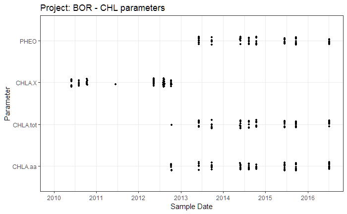

```r
CHL1016_04 %>% filter(PROJ_grp == "BOR") %>%
  ggplot(.,
         aes(y=x_SDate, x=factor(PARAM.X))) + theme_bw() +
  geom_point(na.rm=T,
             position=position_jitter(width=0.1), size=1) +
  xlab("Parameter") + ylab("Sample Date") +
  scale_y_date(date_labels ="%Y",
               date_breaks="1 year",
               limits=c(as.Date("2010-01-01"), NA)) +
  coord_flip() +
  ggtitle("Project: BOR - CHL parameters")
```

**Convert “CHLA.X” to “CHLA.tot” for analyses**

- Reporting Limits over time (*ignoring PHEO*)

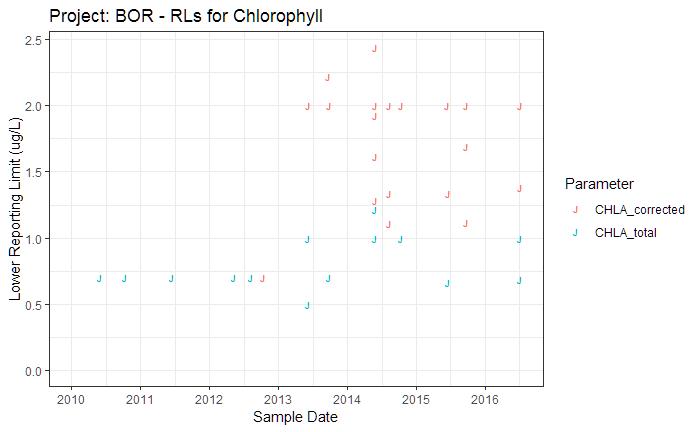

```r
CHL1016_04 %>% filter(PROJ_grp == "BOR" & PARAM.X != "PHEO") %>%
  mutate(PARAM.X = recode(.$PARAM.X,
                          "CHLA.X" = "CHLA_total",
                          "CHLA.tot" = "CHLA_total",
                          "CHLA.aa" = "CHLA_corrected")) %>%
  ggplot(.,
         aes(x=x_SDate, y=LRL_c, col=PARAM.X), na.rm=T) + theme_bw() +
  geom_text(na.rm=T, size=2.5, fontface="bold",
            check_overlap = T,label="J") +
  scale_x_date(date_labels="%Y",date_breaks = "1 year",
               limits=c(as.Date("2010-01-01"), NA)) +
  scale_y_continuous(limits=c(0, NA)) +
  labs(x="Sample Date", y="Lower Reporting Limit (ug/L)", col="Parameter") +
  ggtitle("Project: BOR - RLs for Chlorophyll")
```

- Records where neither an RVal_conc or RL exist :: 2
  - These records have values in LRL, but no Volumes were reported…
- Distinct Records where CHL filtration volume is missing :: 4
- Distinct Records where Filt.Vol is required for CHL-concentration calculation :: 1
  - Record: 4938620.42557.2005353
- Distribution of reporting limits

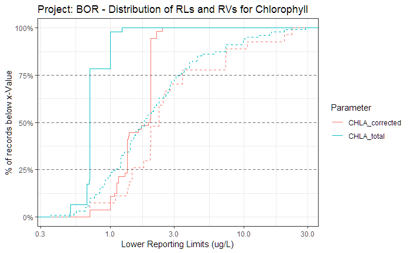

```r
CHL1016_04 %>% filter(PROJ_grp == "BOR" & PARAM.X != "PHEO") %>%
  mutate(PARAM.X = recode(.$PARAM.X,
                          "CHLA.X" = "CHLA_total",
                          "CHLA.tot" = "CHLA_total",
                          "CHLA.aa" = "CHLA_corrected")) %>%
  ggplot(.) + theme_bw() +
  stat_ecdf(aes(x=LRL_c, col=PARAM.X), na.rm=T, lty=1) +
  stat_ecdf(aes(x=x_RVal.conc, col=PARAM.X), na.rm=T, lty=2) +
  labs(x="Lower Reporting Limits (ug/L)", y="% of records below x-Value",
       col="Parameter") +
  scale_x_continuous(trans="log10") +
  scale_y_continuous(labels=percent) +
  geom_hline(yintercept = c(0.25,0.5,0.75), lty=2, color="gray40") +
  ggtitle("Project: BOR - Distribution of RLs and RVs for Chlorophyll")
```

## [2] BRI

- Total Records :: 2195
- Number of CHL-methods :: 1
- Records by PARAM

|  | .$MethodID2 10200 |
| --- | --- |
| .$PARAM.X |  |
| CHLA.aa | 876 |
| CHLA.tot | 443 |
| PHEO | 876 |
| Sum | 2195 |

- Sample Date Range :: [2014-10-27] to [2015-09-23]
- PARAMs over time

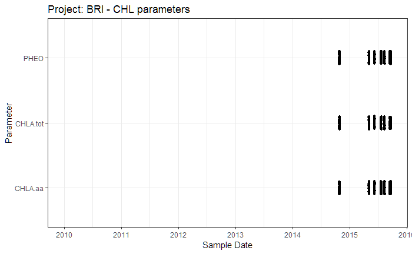

```r
CHL1016_04 %>% filter(PROJ_grp == "BRI") %>%
  ggplot(.,
         aes(y=x_SDate, x=factor(PARAM.X))) + theme_bw() +
  geom_point(na.rm=T,
             position=position_jitter(width=0.1), size=1) +
  xlab("Parameter") + ylab("Sample Date") +
  scale_y_date(date_labels ="%Y",
               date_breaks="1 year",
               limits=c(as.Date("2010-01-01"), NA)) +
  coord_flip() +
  ggtitle("Project: BRI - CHL parameters")
```

**Convert “CHLA.X” to “CHLA.tot” for analyses**

- Reporting Limits over time (*ignoring PHEO*)

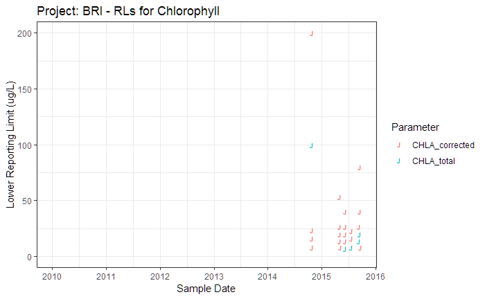

```r
CHL1016_04 %>% filter(PROJ_grp == "BRI" & PARAM.X != "PHEO") %>%
  mutate(PARAM.X = recode(.$PARAM.X,
                          "CHLA.X" = "CHLA_total",
                          "CHLA.tot" = "CHLA_total",
                          "CHLA.aa" = "CHLA_corrected")) %>%
  ggplot(.,
         aes(x=x_SDate, y=LRL_c, col=PARAM.X), na.rm=T) + theme_bw() +
  geom_text(na.rm=T, size=2.5, fontface="bold",
            check_overlap = T,label="J") +
  scale_x_date(date_labels="%Y",date_breaks = "1 year",
               limits=c(as.Date("2010-01-01"), NA)) +
  scale_y_continuous(limits=c(0, NA)) +
  labs(x="Sample Date", y="Lower Reporting Limit (ug/L)", col="Parameter") +
  ggtitle("Project: BRI - RLs for Chlorophyll")
```

- Records where neither an RVal_conc or RL exist :: 98
- Records where CHL filtration volume is missing :: 99
- Distinct Records where CHL filtration volume is missing :: 35
- Distinct Records where Filt.Vol is required for CHL-concentration calculation :: 35

4900751.42128.201502354, 4900751.42207.201504442, 4901100.42205.201504300, 4901225.42163.201503117, 4901225.42261.201505669, 4901730.42129.201502427, 4901980.42262.201505747, 4903030.42262.201505752, 4903260.42206.201504420, 4903400.42207.201504421, 4903400.42263.201505725, 4903820.42263.201505732, 4903950.42269.201505859, 4904110.42130.201502472, 4904240.42207.201504430, 4904370.42164.201503215, 4904510.42165.201503269, 4904940.42227.201504874, 4905000.42129.201502372, 4905030.42206.201504330, 4905040.42129.201502374, 4905052.42129.201502375, 4905150.42164.201503191, 4905170.42129.201502379, 4905200.41940.201405477, 4905301.41940.201405480, 4905400.42206.201504339, 4905630.42227.201504889, 4905640.42130.201502479, 4905640.42206.201504343, 4906100.42206.201504437, 4907120.42268.201505823, 4908735.42129.201502393, 4908735.42269.201505881, 4960740.42128.201502352

- Distribution of reporting limits

```r
CHL1016_04 %>% filter(PROJ_grp == "BRI" & PARAM.X != "PHEO") %>%
  {addmargins(table(.$PARAM.X, .$Non_Detect, useNA="ifany", deparse.level = 2))}
```

```
          .$Non_Detect
.$PARAM.X     U <NA>  Sum
  CHLA.aa   794   82  876
  CHLA.tot  266  177  443
  Sum      1060  259 1319
```

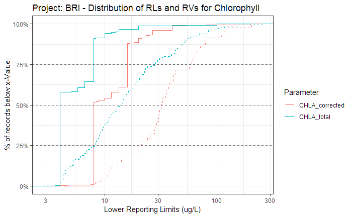

```r
CHL1016_04 %>% filter(PROJ_grp == "BRI" & PARAM.X != "PHEO") %>%
  mutate(PARAM.X = recode(.$PARAM.X,
                          "CHLA.X" = "CHLA_total",
                          "CHLA.tot" = "CHLA_total",
                          "CHLA.aa" = "CHLA_corrected")) %>%
  ggplot(.) + theme_bw() +
  stat_ecdf(aes(x=LRL_c, col=PARAM.X), na.rm=T, lty=1) +
  stat_ecdf(aes(x=x_RVal.conc, col=PARAM.X), na.rm=T, lty=2) +
  labs(x="Lower Reporting Limits (ug/L)", y="% of records below x-Value",
       col="Parameter") +
  scale_x_continuous(trans="log10") +
  scale_y_continuous(labels=percent) +
  geom_hline(yintercept = c(0.25,0.5,0.75), lty=2, color="gray40") +
  ggtitle("Project: BRI - Distribution of RLs and RVs for Chlorophyll")
```

## [3] CUWJ

- Total Records :: 368
- Number of CHL-methods :: 2
  - Methods:: 10200, 447.0
- Records by PARAM

|  | .$MethodID2 10200 | .$MethodID2 447.0 |
| --- | --- | --- |
| .$PARAM.X |  |  |
| CHLA.X | 121 | 99 |
| CHLB | 0 | 49 |
| PHEO | 0 | 99 |
| Sum | 121 | 247 |

- Sample Date Range :: [2010-06-02] to [2016-09-21]
- PARAMs over time

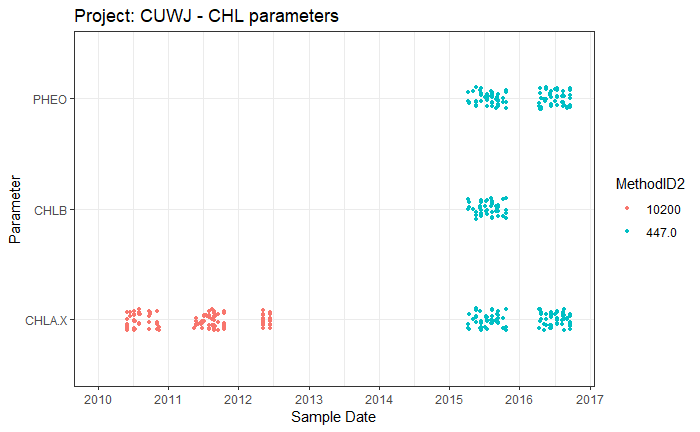

```r
CHL1016_04 %>% filter(PROJ_grp == "CUWJ") %>%
  ggplot(.,
         aes(y=x_SDate, x=factor(PARAM.X),col=MethodID2)) + theme_bw() +
  geom_point(na.rm=T,
             position=position_jitter(width=0.1), size=1) +
  xlab("Parameter") + ylab("Sample Date") +
  scale_y_date(date_labels ="%Y",
               date_breaks="1 year",
               limits=c(as.Date("2010-01-01"), NA)) +
  coord_flip() +
  ggtitle("Project: CUWJ - CHL parameters")
```

**Convert “CHLA.X” to “CHLA.tot” for analyses* **Ignore “CHLB” and “PHEO”**

- Reporting Limits over time (*ignoring PHEO*)

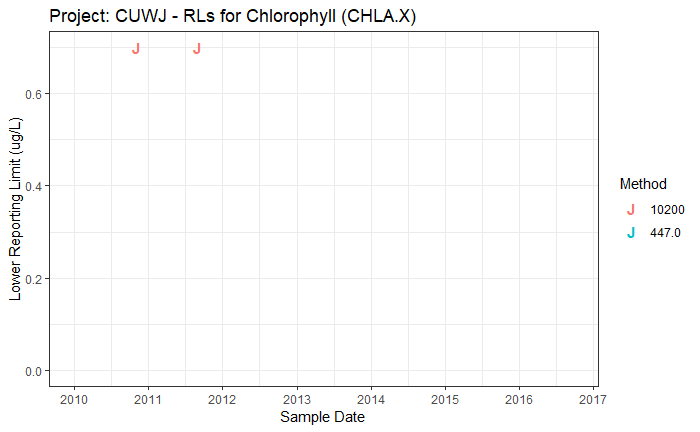

```r
CHL1016_04 %>% filter(PROJ_grp == "CUWJ" & PARAM.X != "PHEO" & PARAM.X != "CHLB") %>%
  mutate(PARAM.X = recode(.$PARAM.X,
                          "CHLA.X" = "CHLA_total",
                          "CHLA.tot" = "CHLA_total",
                          "CHLA.aa" = "CHLA_corrected")) %>%
  ggplot(.,
         aes(x=x_SDate, y=LRL_c, col=MethodID2), na.rm=T) + theme_bw() +
  geom_text(na.rm=T, fontface="bold",
            check_overlap = T,label="J") +
  scale_x_date(date_labels="%Y",date_breaks = "1 year",
               limits=c(as.Date("2010-01-01"), NA)) +
  scale_y_continuous(limits=c(0, NA)) +
  labs(x="Sample Date", y="Lower Reporting Limit (ug/L)", col="Method") +
  ggtitle("Project: CUWJ - RLs for Chlorophyll (CHLA.X)")
```

- Records where neither an RVal_conc or RL exist :: 0
- Records where CHL filtration volume is missing :: 132

**No issue here w/ missing RLs since recent data come from ChemTechFord and results are complete**

- Distinct Records where CHL filtration volume is missing :: 123
- Distinct Records where Filt.Vol is required for CHL-concentration calculation :: 0
- Distribution of reporting limits

```r
CHL1016_04 %>% filter(PROJ_grp == "CUWJ" & PARAM.X != "PHEO" & PARAM.X != "CHLB") %>%
  {addmargins(table(.$PARAM.X, .$Non_Detect, useNA="ifany", deparse.level = 2))}
```

```
         .$Non_Detect
.$PARAM.X   U <NA> Sum
   CHLA.X   4  216 220
   Sum      4  216 220
```

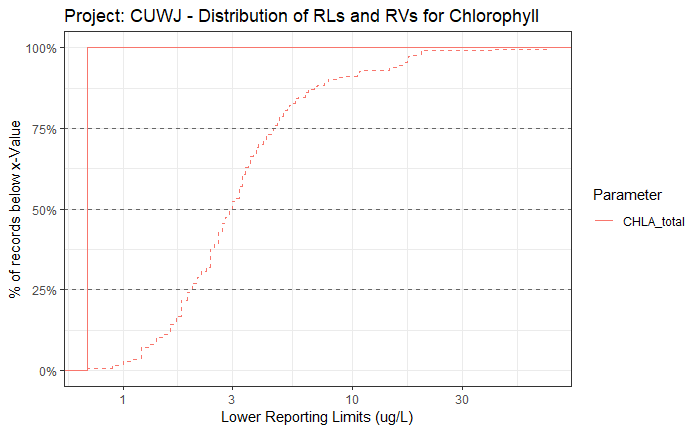

```r
CHL1016_04 %>% filter(PROJ_grp == "CUWJ" & PARAM.X != "PHEO" & PARAM.X != "CHLB") %>%
  mutate(PARAM.X = recode(.$PARAM.X,
                          "CHLA.X" = "CHLA_total",
                          "CHLA.tot" = "CHLA_total",
                          "CHLA.aa" = "CHLA_corrected")) %>%
  ggplot(.) + theme_bw() +
  stat_ecdf(aes(x=LRL_c, col=PARAM.X), na.rm=T, lty=1) +
  stat_ecdf(aes(x=x_RVal.conc, col=PARAM.X), na.rm=T, lty=2) +
  labs(x="Lower Reporting Limits (ug/L)", y="% of records below x-Value",
       col="Parameter") +
  scale_x_continuous(trans="log10") +
  scale_y_continuous(labels=percent) +
  geom_hline(yintercept = c(0.25,0.5,0.75), lty=2, color="gray40") +
  ggtitle("Project: CUWJ - Distribution of RLs and RVs for Chlorophyll")
```

## [4] FarmB

- Only 9 records
- **No filtration Volumes found**
- If data are needed, field-measures must be completed by DPM

## [5] FRNG

- Total Records :: 306
- Number of CHL-methods :: 1
  - Methods:: 10200
- Records by PARAM

|  | .$MethodID2 10200 |
| --- | --- |
| .$PARAM.X |  |
| CHLA.aa | 102 |
| CHLA.tot | 102 |
| PHEO | 102 |
| Sum | 306 |

- Sample Date Range :: [2013-07-10] to [2015-09-15]
- PARAMs over time

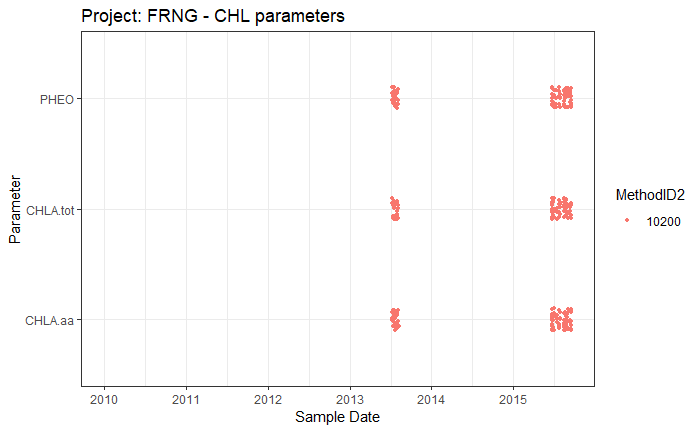

```r
CHL1016_04 %>% filter(PROJ_grp == "FRNG") %>%
  ggplot(.,
         aes(y=x_SDate, x=factor(PARAM.X),col=MethodID2)) + theme_bw() +
  geom_point(na.rm=T,
             position=position_jitter(width=0.1), size=1) +
  xlab("Parameter") + ylab("Sample Date") +
  scale_y_date(date_labels ="%Y",
               date_breaks="1 year",
               limits=c(as.Date("2010-01-01"), NA)) +
  coord_flip() +
  ggtitle("Project: FRNG - CHL parameters")
```

**Convert “CHLA.X” to “CHLA.tot” for analyses**  
**Ignore “CHLB” and “PHEO”**

- Reporting Limits over time (*ignoring PHEO*)

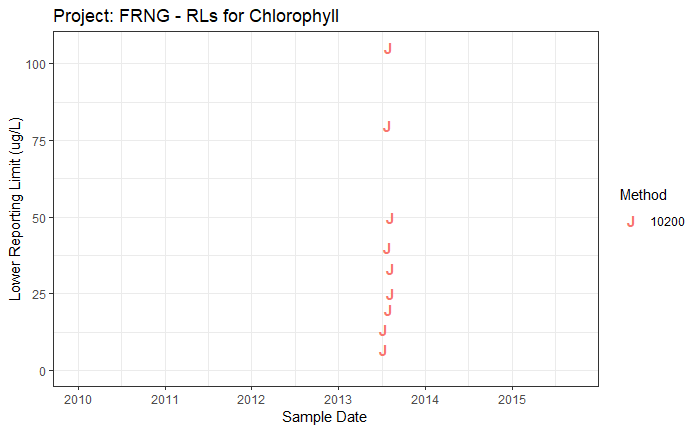

```r
CHL1016_04 %>% filter(PROJ_grp == "FRNG" & PARAM.X != "PHEO" & PARAM.X != "CHLB") %>%
  mutate(PARAM.X = recode(.$PARAM.X,
                          "CHLA.X" = "CHLA_total",
                          "CHLA.tot" = "CHLA_total",
                          "CHLA.aa" = "CHLA_corrected")) %>%
  ggplot(.,
         aes(x=x_SDate, y=LRL_c, col=MethodID2), na.rm=T) + theme_bw() +
  geom_text(na.rm=T, fontface="bold",
            check_overlap = T,label="J") +
  scale_x_date(date_labels="%Y",date_breaks = "1 year",
               limits=c(as.Date("2010-01-01"), NA)) +
  scale_y_continuous(limits=c(0, NA)) +
  labs(x="Sample Date", y="Lower Reporting Limit (ug/L)", col="Method") +
  ggtitle("Project: FRNG - RLs for Chlorophyll")
```

- **Filtration Volumes appear to be missing from ALL 2015 records**
- Records where neither an RVal_conc or RL exist :: 144
- Records where CHL filtration volume is missing :: 144
- Distribution of reporting limits

```r
CHL1016_04 %>% filter(PROJ_grp == "FRNG" & PARAM.X != "PHEO" & PARAM.X != "CHLB") %>%
  {addmargins(table(.$PARAM.X, .$Non_Detect, useNA="ifany", deparse.level = 2))}
```

```
          .$Non_Detect
.$PARAM.X    U <NA> Sum
  CHLA.aa   66   36 102
  CHLA.tot  30   72 102
  Sum       96  108 204
```

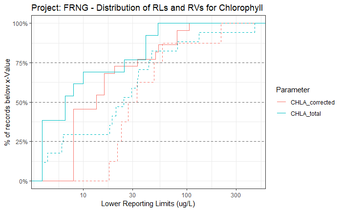

```r
CHL1016_04 %>% filter(PROJ_grp == "FRNG" & PARAM.X != "PHEO" & PARAM.X != "CHLB") %>%
  mutate(PARAM.X = recode(.$PARAM.X,
                          "CHLA.X" = "CHLA_total",
                          "CHLA.tot" = "CHLA_total",
                          "CHLA.aa" = "CHLA_corrected")) %>%
  ggplot(.) + theme_bw() +
  stat_ecdf(aes(x=LRL_c, col=PARAM.X), na.rm=T, lty=1) +
  stat_ecdf(aes(x=x_RVal.conc, col=PARAM.X), na.rm=T, lty=2) +
  labs(x="Lower Reporting Limits (ug/L)", y="% of records below x-Value",
       col="Parameter") +
  scale_x_continuous(trans="log10") +
  scale_y_continuous(labels=percent) +
  geom_hline(yintercept = c(0.25,0.5,0.75), lty=2, color="gray40") +
  ggtitle("Project: FRNG - Distribution of RLs and RVs for Chlorophyll")
```

> **Action** :: Locate and integrate filtration volumes for 2015 FRNG records

## [6] GSLWET

- Total Records :: 333
- Number of CHL-methods :: 1
  - Methods:: 10200
- Records by PARAM

|  | .$MethodID2 10200 |
| --- | --- |
| .$PARAM.X |  |
| CHLA.X | 333 |
| Sum | 333 |

- Sample Date Range :: [2010-01-19] to [2011-11-30]
- These are the historical GSL Wetland records, no corrections should be needed
- PARAMs over time

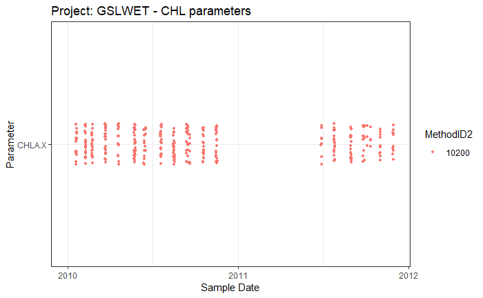

```r
CHL1016_04 %>% filter(PROJ_grp == "GSLWET") %>%
  ggplot(.,
         aes(y=x_SDate, x=factor(PARAM.X),col=MethodID2)) + theme_bw() +
  geom_point(na.rm=T,
             position=position_jitter(width=0.1), size=1) +
  xlab("Parameter") + ylab("Sample Date") +
  scale_y_date(date_labels ="%Y",
               date_breaks="1 year",
               limits=c(as.Date("2010-01-01"), NA)) +
  coord_flip() +
  ggtitle("Project: GSLWET - CHL parameters")
```

**Convert “CHLA.X” to “CHLA.tot” for analyses**  
**Ignore “CHLB” and “PHEO”**

- Reporting Limits over time (*ignoring PHEO*)

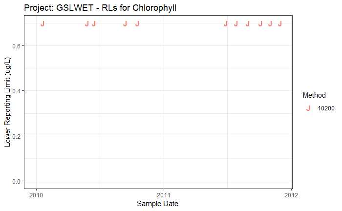

```r
CHL1016_04 %>% filter(PROJ_grp == "GSLWET" & PARAM.X != "PHEO" & PARAM.X != "CHLB") %>%
  mutate(PARAM.X = recode(.$PARAM.X,
                          "CHLA.X" = "CHLA_total",
                          "CHLA.tot" = "CHLA_total",
                          "CHLA.aa" = "CHLA_corrected")) %>%
  ggplot(.,
         aes(x=x_SDate, y=LRL_c, col=MethodID2), na.rm=T) + theme_bw() +
  geom_text(na.rm=T, fontface="bold",
            check_overlap = T,label="J") +
  scale_x_date(date_labels="%Y",date_breaks = "1 year",
               limits=c(as.Date("2010-01-01"), NA)) +
  scale_y_continuous(limits=c(0, NA)) +
  labs(x="Sample Date", y="Lower Reporting Limit (ug/L)", col="Method") +
  ggtitle("Project: GSLWET - RLs for Chlorophyll")
```

- Records where neither an RVal_conc or RL exist :: 0
- Records where CHL filtration volume is missing :: 291
- Distribution of reporting limits

```r
CHL1016_04 %>% filter(PROJ_grp == "GSLWET" & PARAM.X != "PHEO" & PARAM.X != "CHLB") %>%
  {addmargins(table(.$PARAM.X, .$Non_Detect, useNA="ifany", deparse.level = 2))}
```

```
         .$Non_Detect
.$PARAM.X   U <NA> Sum
   CHLA.X  32  301 333
   Sum     32  301 333
```

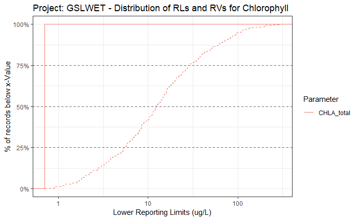

```r
CHL1016_04 %>% filter(PROJ_grp == "GSLWET" & PARAM.X != "PHEO" & PARAM.X != "CHLB") %>%
  mutate(PARAM.X = recode(.$PARAM.X,
                          "CHLA.X" = "CHLA_total",
                          "CHLA.tot" = "CHLA_total",
                          "CHLA.aa" = "CHLA_corrected")) %>%
  ggplot(.) + theme_bw() +
  stat_ecdf(aes(x=LRL_c, col=PARAM.X), na.rm=T, lty=1) +
  stat_ecdf(aes(x=x_RVal.conc, col=PARAM.X), na.rm=T, lty=2) +
  labs(x="Lower Reporting Limits (ug/L)", y="% of records below x-Value",
       col="Parameter") +
  scale_x_continuous(trans="log10") +
  scale_y_continuous(labels=percent) +
  geom_hline(yintercept = c(0.25,0.5,0.75), lty=2, color="gray40") +
  ggtitle("Project: GSLWET - Distribution of RLs and RVs for Chlorophyll")
```

> **Comment:** These records need no correction, but available filtration volumes can be used to (1) calculate effective reporting limits, and (2) estimate Result.Val / RL data distribution for these ecosystem type

## [7] HAB

- Total Records :: 117
- Number of CHL-methods :: 1
  - Methods:: 10200
- Records by PARAM

|  | .$MethodID2 10200 |
| --- | --- |
| .$PARAM.X |  |
| CHLA.aa | 39 |
| CHLA.tot | 39 |
| PHEO | 39 |
| Sum | 117 |

- Sample Date Range :: [2016-07-15] to [2016-11-15]
- These are from 2016 Utah Lake HAB response
- PARAMs over time

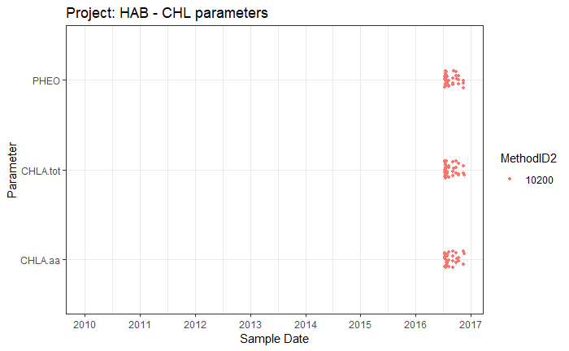

```r
CHL1016_04 %>% filter(PROJ_grp == "HAB") %>%
  ggplot(.,
         aes(y=x_SDate, x=factor(PARAM.X),col=MethodID2)) + theme_bw() +
  geom_point(na.rm=T,
             position=position_jitter(width=0.1), size=1) +
  xlab("Parameter") + ylab("Sample Date") +
  scale_y_date(date_labels ="%Y",
               date_breaks="1 year",
               limits=c(as.Date("2010-01-01"), NA)) +
  coord_flip() +
  ggtitle("Project: HAB - CHL parameters")
```

**Convert “CHLA.X” to “CHLA.tot” for analyses**  
**Ignore “CHLB” and “PHEO”**

- Reporting Limits over time (*ignoring PHEO*)

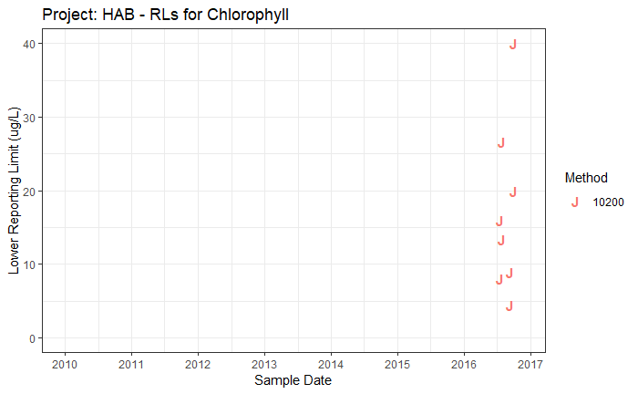

```r
CHL1016_04 %>% filter(PROJ_grp == "HAB" & PARAM.X != "PHEO" & PARAM.X != "CHLB") %>%
  mutate(PARAM.X = recode(.$PARAM.X,
                          "CHLA.X" = "CHLA_total",
                          "CHLA.tot" = "CHLA_total",
                          "CHLA.aa" = "CHLA_corrected")) %>%
  ggplot(.,
         aes(x=x_SDate, y=LRL_c, col=MethodID2), na.rm=T) + theme_bw() +
  geom_text(na.rm=T, fontface="bold",
            check_overlap = T,label="J") +
  scale_x_date(date_labels="%Y",date_breaks = "1 year",
               limits=c(as.Date("2010-01-01"), NA)) +
  scale_y_continuous(limits=c(0, NA)) +
  labs(x="Sample Date", y="Lower Reporting Limit (ug/L)", col="Method") +
  ggtitle("Project: HAB - RLs for Chlorophyll")
```

- Records where neither an RVal_conc or RL exist :: 22
- Records where CHL filtration volume is missing :: 22
  - These are from a partial set of Sites x Dates

```r
CHL1016_04 %>% filter(PROJ_grp == "HAB" & PARAM.X != "PHEO" & PARAM.X != "CHLB") %>% filter(is.na(Filt.Vol)) %>% {addmargins(table(.$x_MLID,.$x_SDate, useNA="ifany", deparse.level=2, dnn=c("Site.ID", "Sample.Date where Filt.Vol is missing")))}
```

```
         Sample.Date where Filt.Vol is missing
Site.ID   2016-07-15 2016-09-06 2016-10-12 2016-11-15 Sum
  4917365          0          2          2          2   6
  4917388          0          0          2          2   4
  4917390          0          2          0          0   2
  4917450          2          0          0          0   2
  4917715          0          2          2          2   6
  4917770          2          0          0          0   2
  Sum              4          6          6          6  22
```

- Distinct Records where CHL filtration volume is missing :: 11
- Distinct Records where Filt.Vol is required for CHL-concentration calculation :: 11

4917365.42619.2020526, 4917365.42655.2027997, 4917365.42689.2033150, 4917388.42655.2028005, 4917388.42689.2033152, 4917390.42619.2020527, 4917450.42566.2008020, 4917715.42619.2020528, 4917715.42655.2027998, 4917715.42689.2033153, 4917770.42566.2008023

- Distribution of reporting limits

```r
CHL1016_04 %>% filter(PROJ_grp == "HAB" & PARAM.X != "PHEO" & PARAM.X != "CHLB") %>%
  {addmargins(table(.$PARAM.X, .$Non_Detect, useNA="ifany", deparse.level = 2))}
```

```
          .$Non_Detect
.$PARAM.X   U <NA> Sum
  CHLA.aa   5   34  39
  CHLA.tot  1   38  39
  Sum       6   72  78
```

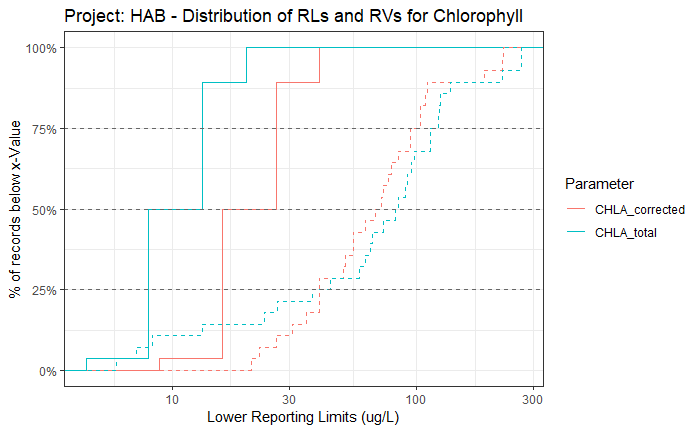

```r
CHL1016_04 %>% filter(PROJ_grp == "HAB" & PARAM.X != "PHEO" & PARAM.X != "CHLB") %>%
  mutate(PARAM.X = recode(.$PARAM.X,
                          "CHLA.X" = "CHLA_total",
                          "CHLA.tot" = "CHLA_total",
                          "CHLA.aa" = "CHLA_corrected")) %>%
  ggplot(.) + theme_bw() +
  stat_ecdf(aes(x=LRL_c, col=PARAM.X), na.rm=T, lty=1) +
  stat_ecdf(aes(x=x_RVal.conc, col=PARAM.X), na.rm=T, lty=2) +
  labs(x="Lower Reporting Limits (ug/L)", y="% of records below x-Value",
       col="Parameter") +
  scale_x_continuous(trans="log10") +
  scale_y_continuous(labels=percent) +
  geom_hline(yintercept = c(0.25,0.5,0.75), lty=2, color="gray40") +
  ggtitle("Project: HAB - Distribution of RLs and RVs for Chlorophyll")
```

> **Action** :: Locate remaining missing filtration volumes

## [8] IW

- Total Records :: 123
- Number of CHL-methods :: 1
  - Methods:: 10200
- Records by PARAM

|  | .$MethodID2 10200 |
| --- | --- |
| .$PARAM.X |  |
| CHLA.tot | 1 |
| CHLA.X | 122 |
| Sum | 123 |

- The outlier record (by PARAM.X) is a duplicated result (*this will be corrected next*)
- Sample Date Range :: [2012-06-21] to [2012-09-19]
- PARAMs over time

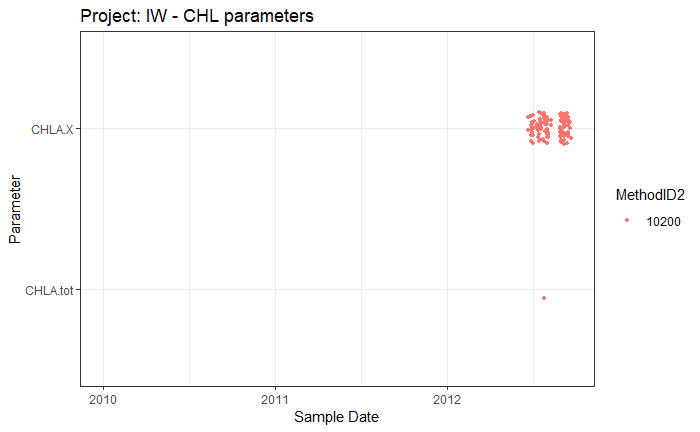

```r
CHL1016_04 %>% filter(PROJ_grp == "IW") %>%
  ggplot(.,
         aes(y=x_SDate, x=factor(PARAM.X),col=MethodID2)) + theme_bw() +
  geom_point(na.rm=T,
             position=position_jitter(width=0.1), size=1) +
  xlab("Parameter") + ylab("Sample Date") +
  scale_y_date(date_labels ="%Y",
               date_breaks="1 year",
               limits=c(as.Date("2010-01-01"), NA)) +
  coord_flip() +
  ggtitle("Project: IW - CHL parameters")
```

**Convert “CHLA.X” to “CHLA.tot” for analyses**  
**Ignore “CHLB” and “PHEO”**

- Reporting Limits over time (*ignoring PHEO*)

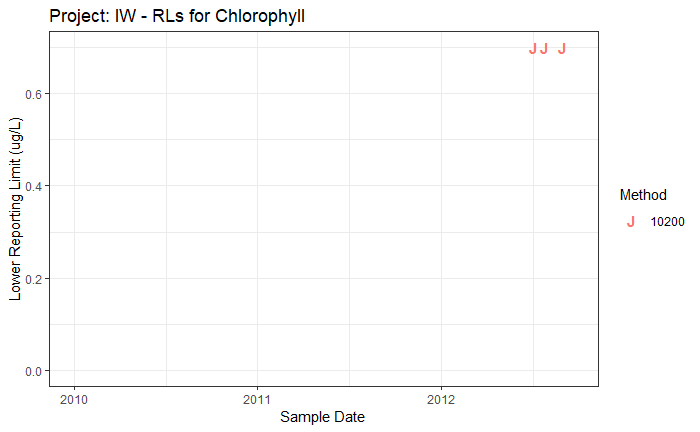

```r
CHL1016_04 %>% filter(PROJ_grp == "IW" & PARAM.X != "PHEO" & PARAM.X != "CHLB") %>%
  mutate(PARAM.X = recode(.$PARAM.X,
                          "CHLA.X" = "CHLA_total",
                          "CHLA.tot" = "CHLA_total",
                          "CHLA.aa" = "CHLA_corrected")) %>%
  ggplot(.,
         aes(x=x_SDate, y=LRL_c, col=MethodID2), na.rm=T) + theme_bw() +
  geom_text(na.rm=T, fontface="bold",
            check_overlap = T,label="J") +
  scale_x_date(date_labels="%Y",date_breaks = "1 year",
               limits=c(as.Date("2010-01-01"), NA)) +
  scale_y_continuous(limits=c(0, NA)) +
  labs(x="Sample Date", y="Lower Reporting Limit (ug/L)", col="Method") +
  ggtitle("Project: IW - RLs for Chlorophyll")
```

- Records where neither an RVal_conc or RL exist :: 0
- Records where CHL filtration volume is missing :: 0
  - These are from a partial set of Sites x Dates

```
CHL1016_04 %>% filter(PROJ_grp == "IW" & PARAM.X != "PHEO" & PARAM.X != "CHLB") %>% filter(is.na(Filt.Vol)) %>% {addmargins(table(.$x_MLID,.$x_SDate, useNA="ifany", deparse.level=2, dnn=c("Site.ID", "Sample.Date where Filt.Vol is missing")))}
```

- Distribution of reporting limits

```r
CHL1016_04 %>% filter(PROJ_grp == "IW" & PARAM.X != "PHEO" & PARAM.X != "CHLB") %>%
  {addmargins(table(.$PARAM.X, .$Non_Detect, useNA="ifany", deparse.level = 2))}
```

```
          .$Non_Detect
.$PARAM.X    U <NA> Sum
  CHLA.tot   0    1   1
  CHLA.X    50   72 122
  Sum       50   73 123
```

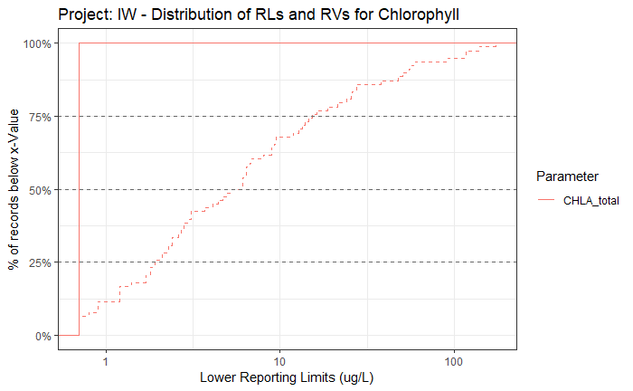

```r
CHL1016_04 %>% filter(PROJ_grp == "IW" & PARAM.X != "PHEO" & PARAM.X != "CHLB") %>%
  mutate(PARAM.X = recode(.$PARAM.X,
                          "CHLA.X" = "CHLA_total",
                          "CHLA.tot" = "CHLA_total",
                          "CHLA.aa" = "CHLA_corrected")) %>%
  ggplot(.) + theme_bw() +
  stat_ecdf(aes(x=LRL_c, col=PARAM.X), na.rm=T, lty=1) +
  stat_ecdf(aes(x=x_RVal.conc, col=PARAM.X), na.rm=T, lty=2) +
  labs(x="Lower Reporting Limits (ug/L)", y="% of records below x-Value",
       col="Parameter") +
  scale_x_continuous(trans="log10") +
  scale_y_continuous(labels=percent) +
  geom_hline(yintercept = c(0.25,0.5,0.75), lty=2, color="gray40") +
  ggtitle("Project: IW - Distribution of RLs and RVs for Chlorophyll")
```

## [9] JRULI

- Total Records :: 1008
- Number of CHL-methods :: 1
  - Methods:: 10200
- Records by PARAM

|  | .$MethodID2 10200 |
| --- | --- |
| .$PARAM.X |  |
| CHLA.tot | 4 |
| CHLA.X | 1004 |
| Sum | 1008 |

- Sample Date Range :: [2010-01-19] to [2012-09-20]
- PARAMs over time

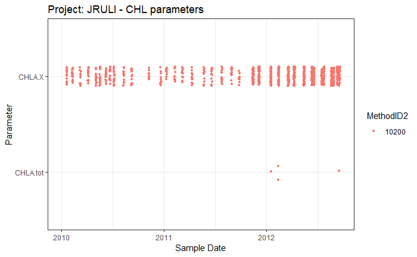

```r
CHL1016_04 %>% filter(PROJ_grp == "JRULI") %>%
  ggplot(.,
         aes(y=x_SDate, x=factor(PARAM.X),col=MethodID2)) + theme_bw() +
  geom_point(na.rm=T,
             position=position_jitter(width=0.1), size=1) +
  xlab("Parameter") + ylab("Sample Date") +
  scale_y_date(date_labels ="%Y",
               date_breaks="1 year",
               limits=c(as.Date("2010-01-01"), NA)) +
  coord_flip() +
  ggtitle("Project: JRULI - CHL parameters")
```

**Convert “CHLA.X” to “CHLA.tot” for analyses**  
**Ignore “CHLB” and “PHEO”**

- Reporting Limits over time (*ignoring PHEO*)

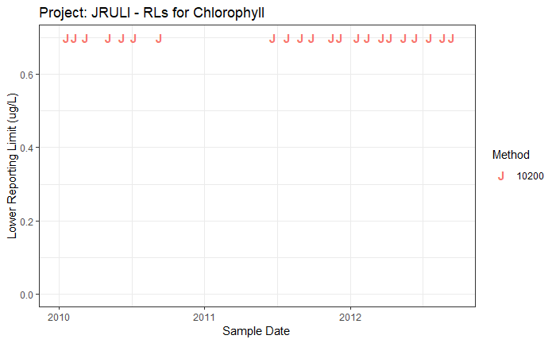

```r
CHL1016_04 %>% filter(PROJ_grp == "JRULI" & PARAM.X != "PHEO" & PARAM.X != "CHLB") %>%
  mutate(PARAM.X = recode(.$PARAM.X,
                          "CHLA.X" = "CHLA_total",
                          "CHLA.tot" = "CHLA_total",
                          "CHLA.aa" = "CHLA_corrected")) %>%
  ggplot(.,
         aes(x=x_SDate, y=LRL_c, col=MethodID2), na.rm=T) + theme_bw() +
  geom_text(na.rm=T, fontface="bold",
            check_overlap = T,label="J") +
  scale_x_date(date_labels="%Y",date_breaks = "1 year",
               limits=c(as.Date("2010-01-01"), NA)) +
  scale_y_continuous(limits=c(0, NA)) +
  labs(x="Sample Date", y="Lower Reporting Limit (ug/L)", col="Method") +
  ggtitle("Project: JRULI - RLs for Chlorophyll")
```

- Records where neither an RVal_conc or RL exist :: 0
- Records where CHL filtration volume is missing :: 321
  - These are from 2010 and 2011, with some 2012 records, where Filt.Vol was not needed

```r
# CHL1016_04 %>% filter(PROJ_grp == "JRULI" & PARAM.X != "PHEO" & PARAM.X != "CHLB") %>% filter(is.na(Filt.Vol)) %>% {addmargins(table(.$x_MLID,paste(lubridate::year(.$x_SDate), lubridate::quarter(.$x_SDate, fiscal_start = 1), sep="."), useNA="ifany", deparse.level=2, dnn=c("Site.ID", "Year-Qtr where Filt.Vol is missing")))}
```

- Distribution of reporting limits

```r
CHL1016_04 %>% filter(PROJ_grp == "JRULI" & PARAM.X != "PHEO" & PARAM.X != "CHLB") %>%
  {addmargins(table(.$PARAM.X, .$Non_Detect, useNA="ifany", deparse.level = 2))}
```

```
          .$Non_Detect
.$PARAM.X     U <NA>  Sum
  CHLA.tot    4    0    4
  CHLA.X    250  754 1004
  Sum       254  754 1008
```

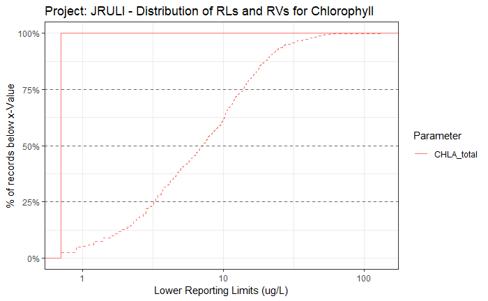

```r
CHL1016_04 %>% filter(PROJ_grp == "JRULI" & PARAM.X != "PHEO" & PARAM.X != "CHLB") %>%
  mutate(PARAM.X = recode(.$PARAM.X,
                          "CHLA.X" = "CHLA_total",
                          "CHLA.tot" = "CHLA_total",
                          "CHLA.aa" = "CHLA_corrected")) %>%
  ggplot(.) + theme_bw() +
  stat_ecdf(aes(x=LRL_c, col=PARAM.X), na.rm=T, lty=1) +
  stat_ecdf(aes(x=x_RVal.conc, col=PARAM.X), na.rm=T, lty=2) +
  labs(x="Lower Reporting Limits (ug/L)", y="% of records below x-Value",
       col="Parameter") +
  scale_x_continuous(trans="log10") +
  scale_y_continuous(labels=percent) +
  geom_hline(yintercept = c(0.25,0.5,0.75), lty=2, color="gray40") +
  ggtitle("Project: JRULI - Distribution of RLs and RVs for Chlorophyll")
```

## [10] LAKES

- Total Records :: 1513
- Number of CHL-methods :: 1
  - Methods:: 10200
- Records by PARAM

|  | .$MethodID2 10200 |
| --- | --- |
| .$PARAM.X |  |
| CHLA.aa | 425 |
| CHLA.tot | 421 |
| CHLA.X | 246 |
| PHEO | 421 |
| Sum | 1513 |

- Sample Date Range :: [2010-06-03] to [2016-10-19]
- PARAMs over time

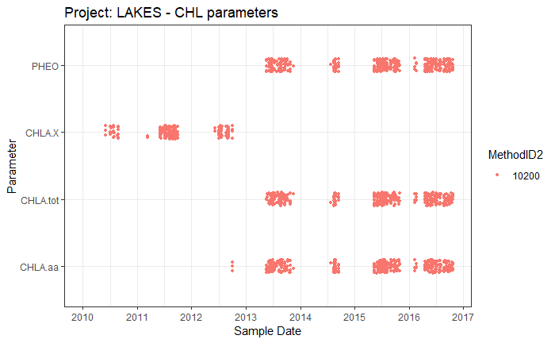

```r
CHL1016_04 %>% filter(PROJ_grp == "LAKES") %>%
  ggplot(.,
         aes(y=x_SDate, x=factor(PARAM.X),col=MethodID2)) + theme_bw() +
  geom_point(na.rm=T,
             position=position_jitter(width=0.1), size=1) +
  xlab("Parameter") + ylab("Sample Date") +
  scale_y_date(date_labels ="%Y",
               date_breaks="1 year",
               limits=c(as.Date("2010-01-01"), NA)) +
  coord_flip() +
  ggtitle("Project: LAKES - CHL parameters")
```

**Convert “CHLA.X” to “CHLA.tot” for analyses**  
**Ignore “CHLB” and “PHEO”**

- Reporting Limits over time (*ignoring PHEO*)

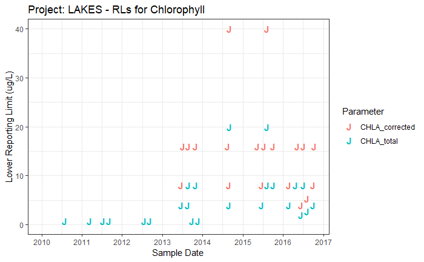

```r
CHL1016_04 %>% filter(PROJ_grp == "LAKES" & PARAM.X != "PHEO" & PARAM.X != "CHLB") %>%
  mutate(PARAM.X = recode(.$PARAM.X,
                          "CHLA.X" = "CHLA_total",
                          "CHLA.tot" = "CHLA_total",
                          "CHLA.aa" = "CHLA_corrected")) %>%
  ggplot(.,
         aes(x=x_SDate, y=LRL_c, col=PARAM.X), na.rm=T) + theme_bw() +
  geom_text(na.rm=T, fontface="bold",
            check_overlap = T,label="J") +
  scale_x_date(date_labels="%Y",date_breaks = "1 year",
               limits=c(as.Date("2010-01-01"), NA)) +
  scale_y_continuous(limits=c(0, NA)) +
  labs(x="Sample Date", y="Lower Reporting Limit (ug/L)", col="Parameter") +
  ggtitle("Project: LAKES - RLs for Chlorophyll")
```

- Records where neither an RVal_conc or RL exist :: 36
- Records where CHL filtration volume is missing :: 84

```r
CHL1016_04 %>% filter(PROJ_grp == "LAKES" & PARAM.X != "PHEO" & PARAM.X != "CHLB") %>% filter(is.na(Filt.Vol)) %>% {addmargins(table(.$MLID.type,lubridate::year(.$x_SDate), useNA="ifany", deparse.level=2, dnn=c("Site.ID", "Year-Qtr where Filt.Vol is missing")))}
```

```
              Year-Qtr where Filt.Vol is missing
Site.ID        2010 2011 2013 2014 2015 2016 Sum
  Lake            2   36    4    4   18   10  74
  River/Stream    4    6    0    0    0    0  10
  Sum             6   42    4    4   18   10  84
```

- Distinct Records where CHL filtration volume is missing :: 48
- Distinct Records where Filt.Vol is required for CHL-concentration calculation :: 18

4900430.42270.201505943, 4900440.42270.201505941, 4900460.42270.201505944, 4900460.42585.2011077, 4917770.41570.201305653, 4936070.41415.201302420, 4940610.42578.2010710, 4940720.42578.2010720, 5900970.42269.201505946, 5900980.42269.201505947, 5900990.42269.201505948, 5901000.42269.201505949, 5901670.42271.201505950, 5901720.42271.201505952, 5941280.41865.201403645, 5941450.42579.2010727, 5941451.42579.2010736, 5951000.41843.201403208

- Distribution of reporting limits

```r
CHL1016_04 %>% filter(PROJ_grp == "LAKES" & PARAM.X != "PHEO" & PARAM.X != "CHLB") %>%
  {addmargins(table(.$PARAM.X, .$Non_Detect, useNA="ifany", deparse.level = 2))}
```

```
          .$Non_Detect
.$PARAM.X     U <NA>  Sum
  CHLA.aa   322  103  425
  CHLA.tot  229  192  421
  CHLA.X     78  168  246
  Sum       629  463 1092
```

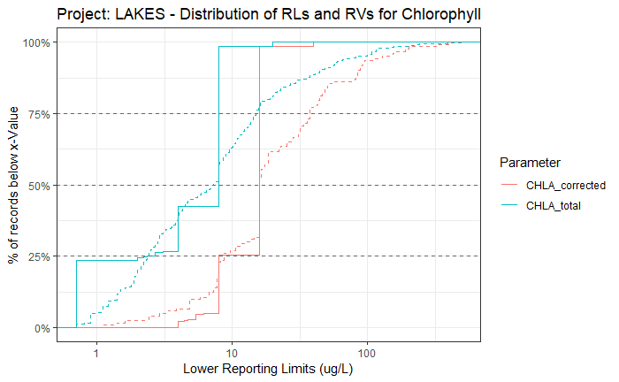

```r
CHL1016_04 %>% filter(PROJ_grp == "LAKES" & PARAM.X != "PHEO" & PARAM.X != "CHLB") %>%
  mutate(PARAM.X = recode(.$PARAM.X,
                          "CHLA.X" = "CHLA_total",
                          "CHLA.tot" = "CHLA_total",
                          "CHLA.aa" = "CHLA_corrected")) %>%
  ggplot(.) + theme_bw() +
  stat_ecdf(aes(x=LRL_c, col=PARAM.X), na.rm=T, lty=1) +
  stat_ecdf(aes(x=x_RVal.conc, col=PARAM.X), na.rm=T, lty=2) +
  labs(x="Lower Reporting Limits (ug/L)", y="% of records below x-Value",
       col="Parameter") +
  scale_x_continuous(trans="log10") +
  scale_y_continuous(labels=percent) +
  geom_hline(yintercept = c(0.25,0.5,0.75), lty=2, color="gray40") +
  ggtitle("Project: LAKES - Distribution of RLs and RVs for Chlorophyll")
```

**Some Data-reporting Issues**

- `RECORD_STATUS` issues:

```r
CHL1016_04 %>% filter(PROJ_grp == "LAKES" & PARAM.X != "PHEO" & PARAM.X != "CHLB") %>% {table(.$RECORD_STATUS, lubridate::year(.$x_SDate), useNA="ifany", deparse.level=2)}
```

```
               lubridate::year(.$x_SDate)
.$RECORD_STATUS 2010 2011 2012 2013 2014 2015 2016
     REVIEW_lrl    0    0    0    0    0    0   24
     REVIEW_mdl    0    0    0    0    0    0   90
     REVIEW_VOL    6   42    0    4    4   18   10
     <NA>         22  118   62  212   70  264  146
```

> **Action** :: Records w/ missing filtration volumes should be reviewed and integrated

## [11] NPS

- Only 3 records
- **No filtration Volumes found**
- If data are needed, field-measures must be completed by DPM

## [12] REFWET

- Total Records :: 99
- Number of CHL-methods :: 1
  - Methods:: 10200
- Records by PARAM

|  | .$MethodID2 10200 |
| --- | --- |
| .$PARAM.X |  |
| CHLA.aa | 33 |
| CHLA.tot | 33 |
| PHEO | 33 |
| Sum | 99 |

- Sample Date Range :: [2014-07-07] to [2015-09-15]
- PARAMs over time

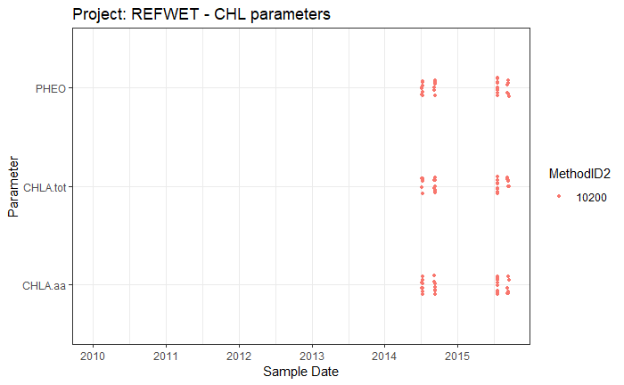

```r
CHL1016_04 %>% filter(PROJ_grp == "REFWET") %>%
  ggplot(.,
         aes(y=x_SDate, x=factor(PARAM.X),col=MethodID2)) + theme_bw() +
  geom_point(na.rm=T,
             position=position_jitter(width=0.1), size=1) +
  xlab("Parameter") + ylab("Sample Date") +
  scale_y_date(date_labels ="%Y",
               date_breaks="1 year",
               limits=c(as.Date("2010-01-01"), NA)) +
  coord_flip() +
  ggtitle("Project: REFWET - CHL parameters")
```

**Convert “CHLA.X” to “CHLA.tot” for analyses**  
**Ignore “CHLB” and “PHEO”**

- Reporting Limits over time (*ignoring PHEO*)

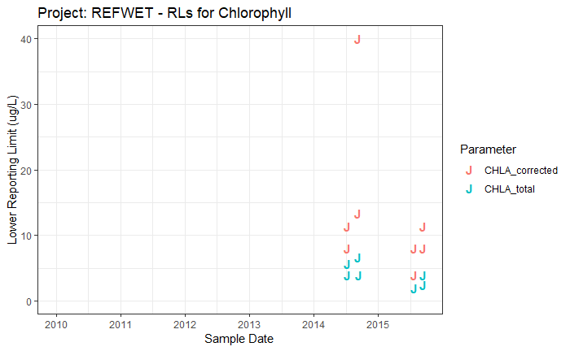

```r
CHL1016_04 %>% filter(PROJ_grp == "REFWET" & PARAM.X != "PHEO" & PARAM.X != "CHLB") %>%
  mutate(PARAM.X = recode(.$PARAM.X,
                          "CHLA.X" = "CHLA_total",
                          "CHLA.tot" = "CHLA_total",
                          "CHLA.aa" = "CHLA_corrected")) %>%
  ggplot(.,
         aes(x=x_SDate, y=LRL_c, col=PARAM.X), na.rm=T) + theme_bw() +
  geom_text(na.rm=T, fontface="bold",
            check_overlap = T,label="J") +
  scale_x_date(date_labels="%Y",date_breaks = "1 year",
               limits=c(as.Date("2010-01-01"), NA)) +
  scale_y_continuous(limits=c(0, NA)) +
  labs(x="Sample Date", y="Lower Reporting Limit (ug/L)", col="Parameter") +
  ggtitle("Project: REFWET - RLs for Chlorophyll")
```

- Records where neither an RVal_conc or RL exist :: 0
- Records where CHL filtration volume is missing :: 0
- Distribution of reporting limits

```r
CHL1016_04 %>% filter(PROJ_grp == "REFWET" & PARAM.X != "PHEO" & PARAM.X != "CHLB") %>%
  {addmargins(table(.$PARAM.X, .$Non_Detect, useNA="ifany", deparse.level = 2))}
```

```
          .$Non_Detect
.$PARAM.X   U <NA> Sum
  CHLA.aa  32    1  33
  CHLA.tot 26    7  33
  Sum      58    8  66
```

- Many non-detects in this project

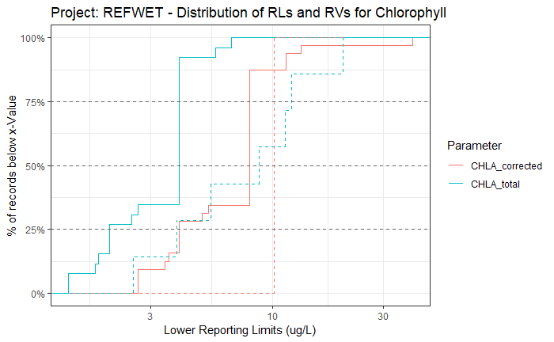

```r
CHL1016_04 %>% filter(PROJ_grp == "REFWET" & PARAM.X != "PHEO" & PARAM.X != "CHLB") %>%
  mutate(PARAM.X = recode(.$PARAM.X,
                          "CHLA.X" = "CHLA_total",
                          "CHLA.tot" = "CHLA_total",
                          "CHLA.aa" = "CHLA_corrected")) %>%
  ggplot(.) + theme_bw() +
  stat_ecdf(aes(x=LRL_c, col=PARAM.X), na.rm=T, lty=1) +
  stat_ecdf(aes(x=x_RVal.conc, col=PARAM.X), na.rm=T, lty=2) +
  labs(x="Lower Reporting Limits (ug/L)", y="% of records below x-Value",
       col="Parameter") +
  scale_x_continuous(trans="log10") +
  scale_y_continuous(labels=percent) +
  geom_hline(yintercept = c(0.25,0.5,0.75), lty=2, color="gray40") +
  ggtitle("Project: REFWET - Distribution of RLs and RVs for Chlorophyll")
```

- This dataset appears to be complete